# SIRUP walkthrough with MG thymus slice 2

Hunter J. Melton

```r
knitr::opts_chunk$set(
  echo = TRUE,
  message = TRUE,
  warning = TRUE,
  fig.width = 8,
  fig.height = 7,
  dpi = 120
)

library(dplyr)
library(stringr)
library(data.table)
library(ggplot2)
library(cowplot)
library(airr)
library(Seurat)
library(SeuratObject)
library(scoper)
library(dowser)
library(alakazam)

hunter_dir <- "/Volumes/HoehnK/Hunter"

chinmay_dir <- "/Volumes/HoehnK/Chinmay"

sirup_dir <- file.path(hunter_dir, "spatial_bcr_tcr_package", "SIRUP")
thymus_dir <- file.path(hunter_dir, "Thymus_Spatial")
walkthrough_dir <- file.path(thymus_dir, "sirap_lab_vignette", "mg_thymus_slice2")
dir.create(walkthrough_dir, recursive = TRUE, showWarnings = FALSE)

devtools::load_all(sirup_dir, quiet = TRUE)

sample_id <- "KH02"
dataset <- "mg_thymus_slice2"
nproc <- 2
image_scale <- "lowres"
swap_coords <- TRUE # For standard Visium objects, the coordinates need to be swapped to get the correct shape
```

Starting with RAD-processed output for Visium thymus (igblast_bcr.tsv) slice 2. We’ll take a full tour of SIRUP and the major functionality.

# 1 Start with the RAD/IgBLAST output

The starting BCR table is the direct IgBLAST output made after RAD demultiplexing.

```r
raw_bcr_path <- file.path(
  chinmay_dir,
  "101724_KH02_compiled_out",
  "igblast_data",
  "igblast_bcr_10k.tsv"
)

# This is a 24 GB read-level table, so we just get 10k sequences
raw_bcrs <- data.table::fread(
  raw_bcr_path,
  data.table = FALSE,
  nThread = nproc,
  showProgress = FALSE
)

raw_bcrs <- extractSpatialIds(
  raw_bcrs,
  id = "sequence_id",
  spatial_id = "barcode",
  regex = "\\|barcode:([ACGT]{16})(?:\\||$)"
)

raw_bcrs$sample_id <- sample_id

raw_bcrs %>% select(sequence_id, barcode) %>% head(3)
```

```
##                                                                    sequence_id
## 1 bf4d96ca-c609-473e-86fb-b0b129029286|umi:TATTTTTCGC|barcode:TACCGTAGGTTAACTA
## 2 d187b70b-6426-43c0-9512-ebe17c61802e|umi:GCAAACGGAG|barcode:AGCACCAGTACTCACG
## 3 777f7145-9a30-4763-9d7c-e0b4dcca6c00|umi:TATCGCTATC|barcode:GTGCTGCAGATAAGGA
##            barcode
## 1 TACCGTAGGTTAACTA
## 2 AGCACCAGTACTCACG
## 3 GTGCTGCAGATAAGGA
```

Now we’ll filter the spAIRR data with `filterAirr()`, which is another convenience function to do the sort of filtering we’ve always done with spAIRR data. We have options to filter for locus, min v, j, junction length, productivity, min consensus count, and we point towards the spatial ID column (technically optional argument). We don’t do it here, but we can also filter for max opening gap in the seqeuence alignment column (max_opening_gap), and we can also add a `spatial_sequence_id` (`add_spatial_sequence_id = TRUE`) which combines the sequence_id and the spatial ID columns.

Then I made another convenience function that plots the v, j, and junction lengths, `plotLengthQc()`. That’s all it does, but we’ve often used those plots, so I figured why not. spatialReceptorSummary is similar, it’s a convenience function that prints the number of sequences, spatial IDs, loci, and productive sequences.

```r
raw_igh <- filterAirr(
  raw_bcrs,
  locus_val = "IGH",
  min_v_length = 100,
  min_j_length = 10,
  min_junction_length = 1,
  productive_only = TRUE,
  min_consensus_count = 2,
  spatial_id = "barcode"
)
```

```
## filterAirr kept 26 of 9999 rows (dropped 9973).
```

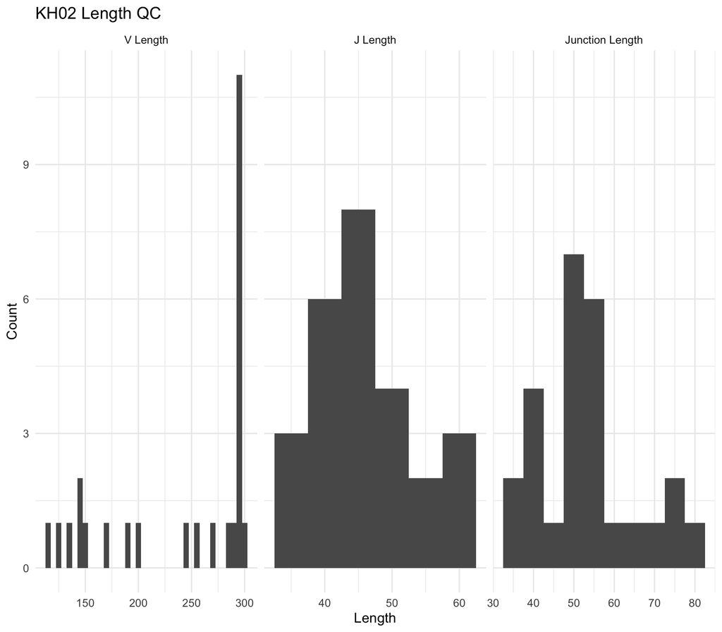

```r
plotLengthQc(raw_igh, bin_width = 5, title = "KH02 Length QC")
```

```r
spatialReceptorSummary(raw_igh, spatial_id = "barcode")
```

```
## # A tibble: 1 × 4
##   n_sequences n_spatial_ids n_loci n_productive
##         <int>         <int>  <int>        <int>
## 1          26            26      1           26
```

# 2 Post RAD major processing step - `processSpatialSample()`

Before running `processSpatialSample()` and doing the major processing, we’ll convert the raw_igh dataframe into a fasta file using dowser’s `dfToFasta()` function. We’ll also pretend that we want to carry a c_call column through the processing, so we add that to the sequence id so that it gets written to the fasta header. We’re not actually going to run this locally because it takes a while.

`processSpatialSample()` takes the spAIRR processing pipeline we made and wraps it up in a single R function. It takes in a fasta file (and a lot of arguments for the different steps) and returns a list of paths to the processed output. This function is a wrapper around

- `ClusterSets.py set` groups reads within each spatial ID `cluster_field`, the requested identity threshold `identity`, and vsearch. FASTA header delimiters are specified by `delimiters` (i.e., | then : then ,).
- `ParseHeaders.py merge` is used to write a new field into the headers that combines the spatial ID and the cluster id (provided with parse_fields). These are combined using `parse_act` (default cat) and written to a new header field `parse_key`. Uses `delimiters` to specify the FASTA header delimiters.
- `AlignSets.py muscle` aligns reads within each `parse_key` group created by `ParseHeaders`. Takes `muscle_exec` as the path to the muscle aligner (https://github.com/rcedgar/muscle). Optionally logs results to `align_log`. Uses `delimiters` to specify the FASTA header delimiters.
- `BuildConsensus.py` creates consensus sequences within each `parse_key` group. `consensus_min_count` specifies the minimum number of sequences needed to define a valid consensus sequence, and `consensus_freq` specifies the fraction of character occurrences under which an ambiguous character is assigned. Optionally logs results to `consensus_log`. If there are additional fields in the FASTA header that should be carried forward and copied to the consensus file, `consensus_copy_fields` specifies the field names and `consensus_copy_action` specifies how to copy them (majority, first, last, or all).
- `AssignGenes.py igblast` assigns V(D)J gene annotations using IgBLAST. Takes either `ig` or `tr` as the argument to `receptor` (for bcr/tcr respectively). Takes `organism` as the argument to specify the species (e.g., human, mouse, etc.). `igblast_base` specifies the path to the IgBLAST installation, and `igblast_exec` can be provided if the igblast executable is not located in [`igblast_base`]/bin/igblastn.
- `MakeDb.py igblast` converts IgBLAST output to an AIRR-style TSV using the specified IMGT germline reference `germline_glob`.

Note that if we have multiple samples we can use `processSpatialSamples()`, which takes vectors of `input_fastas` and `output_dirs` and then all other arguments for `processSpatialSample()` and calls `processSpatialSample()` for each sample.

```r
presto_input_dir <- file.path(walkthrough_dir, "processing_input")
presto_output_dir <- file.path(walkthrough_dir, "processing_output")
dir.create(presto_input_dir, recursive = TRUE, showWarnings = FALSE)
dir.create(presto_output_dir, recursive = TRUE, showWarnings = FALSE)

raw_igh <- fread(file.path(presto_input_dir, "filtered_igh.tsv"), data.table = FALSE)

raw_igh$c_call_for_header <- ifelse(
  is.na(raw_igh$c_call) | raw_igh$c_call == "",
  "NA",
  raw_igh$c_call
)
raw_igh$seq_id_c_call <- paste0(
  raw_igh$sequence_id,
  "|c_call_og:",
  raw_igh$c_call_for_header
)

presto_input_fasta <- file.path(presto_input_dir, "filtered_igh.fasta")
dowser::dfToFasta(
  raw_igh,
  file = presto_input_fasta,
  id = "seq_id_c_call",
  seq = "sequence_alignment"
)

processed_paths <- processSpatialSample(
  input_fasta = presto_input_fasta,
  output_dir = presto_output_dir,
  receptor = "ig",
  identity = 1.0,
  consensus_freq = 0.8,
  germline_glob = file.path(
    hunter_dir,
    "germlines/imgt/human/vdj/imgt_human_IG*.fasta"
  ),
  igblast_base = "~/software/igblast",
  muscle_exec = "~/software/muscle3.8.31_i86linux64",
  nproc = nproc,
  cluster_field = "barcode",
  delimiters = "'|' ':' ','",
  parse_fields = c("BARCODE", "CLUSTER"),
  parse_key = "BARCODECLUSTER",
  parse_act = "cat",
  consensus_min_count = 2,
  consensus_copy_fields = "C_CALL_OG",
  consensus_copy_action = "majority"
)
```

Now that we have the processed BCRs, we’ll do a little more filtering with `filterAirr()`, which, again, is a convenience function that filters for v gene length (`min_v_length`), j gene length (`min_j_length`), junction length (`min_junction_length`), locus values (`locus_val`), minimum consensus count (`min_consensus_count`), maximum gap to start the sequence - spAIRR data can often be very …………….AGC at the beginning of sequences (`max_opening_gap`). We also specify the `sequence_alignment`, `id`, and `spatial_id`. To make things easier later and ensure we have unique identifiers for mixed datasets, we can also request a `spatial_sequence_id` be made by combining the sequence id and the spatial ID with `add_spatial_sequence_id`, and we can name the spatial ID field in that ID with `spatial_id_key`. How much we really needed this function I’m not sure, but I did this sort of filtering enough that I was okay with having an easy way to do it in the package. Prior to using `filterAirr()`, we extract the spatial ID from the `sequence_id` column with `extractSpatialIds()`, which is just a quick function that pulls a regex from a column and puts it in a new column. We also add a `consensus_count` column and receptor type column.

```r
processed_bcr_path <- file.path(
  thymus_dir,
  "sirap_visium_processing",
  sample_id,
  "bcr",
  "presto_output",
  paste0(
    "filtered_igh_ident_1.0_barcode_cluster_freq_0.8_cluster-pass_",
    "reheader_align-pass_consensus-pass_igblast_db-pass.tsv"
  )
)

processed_bcrs <- airr::read_rearrangement(processed_bcr_path)
processed_bcrs %>% select(sequence_id, sequence_alignment)
```

```
## # A tibble: 4,782 × 2
##    sequence_id                                                sequence_alignment
##    <chr>                                                      <chr>
##  1 CAGTGTTAATCTCTCA10|CONSCOUNT:2|C_CALL_OG:NA|C_CALL_OG_FRE… .................…
##  2 CAGTGTTAATCTCTCA11|CONSCOUNT:3|C_CALL_OG:NA|C_CALL_OG_FRE… .................…
##  3 CAGTGTTAATCTCTCA19|CONSCOUNT:2|C_CALL_OG:NA|C_CALL_OG_FRE… .................…
##  4 CAGTGTTAATCTCTCA7|CONSCOUNT:3|C_CALL_OG:NA|C_CALL_OG_FREQ… .................…
##  5 CAGTGTTAATCTCTCA29|CONSCOUNT:3|C_CALL_OG:IGHG1*03|C_CALL_… .................…
##  6 CAGTGTTAATCTCTCA62|CONSCOUNT:2|C_CALL_OG:IGHA1*01,IGHA1*0… .................…
##  7 CAGTGTTAATCTCTCA39|CONSCOUNT:7|C_CALL_OG:IGHA1*01,IGHA1*0… .................…
##  8 CAGTGTTAATCTCTCA31|CONSCOUNT:2|C_CALL_OG:IGHA1*01,IGHA1*0… .................…
##  9 CTGAATCCGAGACCTC7|CONSCOUNT:4|C_CALL_OG:IGHG3*11|C_CALL_O… .................…
## 10 CCGGAGCGTACTTTCT17|CONSCOUNT:2|C_CALL_OG:IGHG1*03|C_CALL_… CAGCTGCAGCTGCAGGA…
## # ℹ 4,772 more rows
```

```r
processed_bcrs <- processed_bcrs %>%
  extractSpatialIds(
    id = "sequence_id",
    spatial_id = "barcode_10x",
    regex = "^[ACGT]{16}",
    suffix = "-1"
  ) %>%
  mutate(
    consensus_count = as.integer(str_match(sequence_id, "CONSCOUNT:([0-9]+)")[, 2]),
    receptor_type = "BCR"
  )
processed_bcrs %>% select(sequence_id, barcode_10x, consensus_count, receptor_type) %>%
  head()
```

```
## # A tibble: 6 × 4
##   sequence_id                          barcode_10x consensus_count receptor_type
##   <chr>                                <chr>                 <int> <chr>
## 1 CAGTGTTAATCTCTCA10|CONSCOUNT:2|C_CA… CAGTGTTAAT…               2 BCR
## 2 CAGTGTTAATCTCTCA11|CONSCOUNT:3|C_CA… CAGTGTTAAT…               3 BCR
## 3 CAGTGTTAATCTCTCA19|CONSCOUNT:2|C_CA… CAGTGTTAAT…               2 BCR
## 4 CAGTGTTAATCTCTCA7|CONSCOUNT:3|C_CAL… CAGTGTTAAT…               3 BCR
## 5 CAGTGTTAATCTCTCA29|CONSCOUNT:3|C_CA… CAGTGTTAAT…               3 BCR
## 6 CAGTGTTAATCTCTCA62|CONSCOUNT:2|C_CA… CAGTGTTAAT…               2 BCR
```

```r
processed_bcrs <- filterAirr(
  processed_bcrs,
  locus_val = "IGH",
  min_v_length = 100,
  min_j_length = 10,
  min_junction_length = 1,
  productive_only = TRUE,
  min_consensus_count = 2,
  spatial_id = "barcode_10x"
)
```

```
## filterAirr kept 3751 of 4782 rows (dropped 1031).
```

```r
spatialReceptorSummary(processed_bcrs, spatial_id = "barcode_10x")
```

```
## # A tibble: 1 × 4
##   n_sequences n_spatial_ids n_loci n_productive
##         <int>         <int>  <int>        <int>
## 1        3751           972      1         3751
```

```r
summary(processed_bcrs$consensus_count)
```

```
##    Min. 1st Qu.  Median    Mean 3rd Qu.    Max.
##   2.000   2.000   3.000   4.875   5.000 159.000
```

# 3 Load the spatial Seurat object

```r
seurat_path <- file.path(
  thymus_dir,
  "data/240814_Visium/Intermediates/51T002-M5b/thy2_b_t_processed_seurat.rds"
)

mg_thymus_slice2 <- readRDS(seurat_path)
mg_thymus_slice2
```

```
## An object of class Seurat
## 73202 features across 3203 samples within 2 assays
## Active assay: alra (36601 features, 0 variable features)
##  1 layer present: data
##  1 other assay present: Spatial
##  2 dimensional reductions calculated: pca, umap
##  1 spatial field of view present: slice1
```

```r
# Reuse the saved GC polygon file when it is already available. If this file
# does not exist, the object is created without polygons and the selection
# section below adds them with addPolygons().
polygon_path <- file.path(
  thymus_dir,
  "plots/gc_clonal_dominance/mg_thymus_slice2",
  "mg_thymus_slice2_gc_polygons_vertices.csv"
)

complex_polygon_path <- file.path(
  thymus_dir,
  "plots/gc_clonal_dominance/mg_thymus_slice2",
  "mg_thymus_slice2_complex_polygons_vertices.csv"
)
```

# 4 Make a SIRUP object

A SIRUP object is our native S3 object for spAIRR data. At base level, it consists of a spatial Seurat object (`spatial`), an AIRR-style receptor table (`receptors`), and a canonical polygon table (`polygons`). When we create a SIRUP object, we pass a barcode column (`barcode`) from the spAIRR data that corresponds to the barcodes in the Seurat object, i.e., the column names in the GEX matrix. Optional arguments for a clone ID column (`clone`), a locus column (`locus`), and a consensus count column (`count`) exist too. The SIRUP object also has a list of metadata (`metadata`) and a list of derived analyses (`analyses`). Polygon geometry can be supplied at creation time with `polygons_path`, or attached later with `addPolygons()` after an interactive polygon-selection step.

The metadata list stores common receptor column names and other information about the sample. It includes the `dataset` (“mg_thymus_slice2”), the `sample_id` (“KH02”), and important columns from the receptors dataframe `receptor_fields`. `receptor_fields` is itself a list that includes the `barcode` column name (“barcode_10x”), the `image` column name (currently NULL), the `sample` column name, the `clone` column name (“clone_id”), the `locus` column name (“locus”), and the `count` column name (“consensus_count”). The idea here is that sometimes the receptor data has different column names (like clone_family_id in the original Engblom tonsil data), and we want to make the SIRUP object easily respect those.

When working with a SIRUP object, we can use `getSpatial()` to get the Seurat object, `getReceptors()` to get the receptor table, and `listAnalyses()` to see what analyses have been run and stored in the object. We can also use `summary()` to get a quick overview. When we want to inspect the spatial data or receptor table with outside code, we can pass `getSpatial()` or `getReceptors()` directly to that code. When we want the result stored back inside the object, we can use `updateSpatial()` or `updateReceptors()`. Finally, we can store the results of an analysis in the SIRUP object with `setAnalysis()` and retrieve it with `getAnalysis()`. We can update a stored analysis with `updateAnalysis()`. Polygon geometry can be retrieved with `getPolygons()`.

The polygon slot stores one row per polygon, with a `polygon_id` and a nested `vertices` tibble containing the boundary coordinates and, when available, the spatial IDs used to define those vertices. Derived quantities such as BCR abundance or diversity remain in the `analyses` slot, so the geometry is separated from any one filtering or summary choice.

```r
mg_thymus_slice2_sirup <- createSIRUP(
  spatial = mg_thymus_slice2,
  receptors = processed_bcrs,
  spatial_id = "barcode_10x",
  clone = NULL,
  locus = "locus",
  count = "consensus_count",
  image_scale = image_scale,
  swap_coords = swap_coords,
  polygons_path = polygon_path,
  metadata = list(dataset = dataset, sample_id = sample_id)
)

mg_thymus_slice2_sirup
```

```
## <SIRUP object>
## Spatial data:    Seurat, 3,203 spatial IDs, 36,601 genes, 1 image
## Receptor data:   tibble, 3,751 receptor sequences x 63 columns
## Spatial overlap: 909/972 receptor IDs in spatial data (93.5%)
## Spatial ID field: barcode_10x
## Analyses:        0
## Polygons:        8
```

```r
summary(mg_thymus_slice2_sirup)
```

```
## SIRUP summary
##   Spatial IDs:      3,203
##   Receptor records: 3,751
##   Receptor IDs:     972
##   Matched IDs:      909 (93.5%)
##   Matched records:  3,541
##   Stored analyses:  0
##   Polygons:         8
```

```r
getSpatial(mg_thymus_slice2_sirup)
```

```
## An object of class Seurat
## 73202 features across 3203 samples within 2 assays
## Active assay: alra (36601 features, 0 variable features)
##  1 layer present: data
##  1 other assay present: Spatial
##  2 dimensional reductions calculated: pca, umap
##  1 spatial field of view present: slice1
```

```r
getReceptors(mg_thymus_slice2_sirup) %>% head()
```

```
## # A tibble: 6 × 63
##   sequence_id                  sequence rev_comp productive v_call d_call j_call
##   <chr>                        <chr>    <lgl>    <lgl>      <chr>  <chr>  <chr>
## 1 CAGTGTTAATCTCTCA10|CONSCOUN… ATATACA… FALSE    TRUE       IGHV1… IGHD3… IGHJ4…
## 2 CAGTGTTAATCTCTCA11|CONSCOUN… ATATACA… FALSE    TRUE       IGHV1… IGHD3… IGHJ4…
## 3 CAGTGTTAATCTCTCA19|CONSCOUN… GGCCCCT… FALSE    TRUE       IGHV1… IGHD3… IGHJ4…
## 4 CAGTGTTAATCTCTCA39|CONSCOUN… ATCAAAT… FALSE    TRUE       IGHV3… IGHD2… IGHJ4…
## 5 CAGTGTTAATCTCTCA31|CONSCOUN… ATCAAAT… FALSE    TRUE       IGHV3… IGHD5… IGHJ4…
## 6 CTGAATCCGAGACCTC7|CONSCOUNT… GGTTACA… FALSE    TRUE       IGHV1… IGHD3… IGHJ6…
## # ℹ 56 more variables: sequence_alignment <chr>, germline_alignment <chr>,
## #   junction <chr>, junction_aa <chr>, v_cigar <chr>, d_cigar <chr>,
## #   j_cigar <chr>, stop_codon <lgl>, vj_in_frame <lgl>, locus <chr>,
## #   c_call <chr>, junction_length <int>, np1_length <int>, np2_length <int>,
## #   v_sequence_start <int>, v_sequence_end <int>, v_germline_start <int>,
## #   v_germline_end <int>, d_sequence_start <int>, d_sequence_end <int>,
## #   d_germline_start <int>, d_germline_end <int>, j_sequence_start <int>, …
```

```r
listAnalyses(mg_thymus_slice2_sirup)
```

```
## character(0)
```

```r
getPolygons(mg_thymus_slice2_sirup)
```

```
## # A tibble: 8 × 2
##   polygon_id vertices
##   <chr>      <named list>
## 1 1          <tibble [8 × 4]>
## 2 2          <tibble [9 × 4]>
## 3 3          <tibble [10 × 4]>
## 4 4          <tibble [8 × 4]>
## 5 5          <tibble [5 × 4]>
## 6 6          <tibble [6 × 4]>
## 7 7          <tibble [6 × 4]>
## 8 8          <tibble [7 × 4]>
```

SIRUP objects can also be saved at natural stopping points in the analysis. `saveSIRUP()` writes the object to an RDS file after validating it and recording the SIRUP and SeuratObject versions used to save it. `readSIRUP()` loads the object back in, updates older object schemas when needed, warns if the saved package versions differ from the versions currently installed, and validates the object before returning it. This is useful after a slow processing step or before moving the same object between machines.

```r
sirup_checkpoint_path <- file.path(
  walkthrough_dir,
  "mg_thymus_slice2_checkpoint.sirap.rds"
)

saveSIRUP(mg_thymus_slice2_sirup, sirup_checkpoint_path)

mg_thymus_slice2_sirup <- readSIRUP(sirup_checkpoint_path)
```

# 5 Check for identical sequences in neighboring spots

SIRUP can collapse the same exact sequence observed in neighboring spots with `collapseIdenticalNeighbors()`. Input is a SIRUP object, so the function uses the receptor ID field recorded in the object and pulls coordinates from the stored Seurat object.

We know that spatial sequencing data suffers from bleed between spots, so we don’t necessarily want to count the same exact sequence in neighboring spots unless we’re quite sure that this represents distinct cells. I wouldn’t recommend running this function on standard 10X Visium data, since each 55um spot has multiple cells and spots are 100um away from each other. Absolutely use it with Visium HD data.

`collapseIdenticalNeighbors()` estimates the neighbor distance threshold from all tissue coordinates, so it’s very important to get `num_neighbors_non_boundary` correct. For standard Visium data, this is 6 because it’s a hex grid, for Visium HD data, this is 8 because it’s a continuous lawn. It estimates the spatial neighbor distance from a downsampled version of the tissue coordinates using RANN’s `knn()` to do nearest neighbor searching with a kd-tree. Then we take all of the unique distances and do a kernel smoothing and use the first local minimum as the distance threshold (extremely similar to the threshold selection in hierarchicalClones).

Then we filter to spots with observed receptor sequences and build an undirected adjacency graph from those spots using the distance threshold to define adjacency (i.e., neighbors). Then, for every unique sequence, we look in each component of of the graph and find connected spots that have the same sequence represented.For each component, we choose one representative spot. First pick the row with the highest consensus_count, if there is a tie, choose the spot closest to the component centroid. If there is still a tie, pick one at random.

```r
image_name <- Images(getSpatial(mg_thymus_slice2_sirup))[1]
image_name
```

```
## [1] "slice1"
```

```r
neighbor_collapsed_sirup <- collapseIdenticalNeighbors(
  mg_thymus_slice2_sirup,
  num_neighbors_non_boundary = 6
)
```

```
## ℹ Ensuring one row per spatial_id/sequence...✔ Ensuring one row per spatial_id/sequence... [7.7s]
## ℹ Estimating distance threshold from full tissue positions...✔ Estimating distance threshold from full tissue positions... [2.4s]
## ℹ Distance threshold: 9.8988
## ℹ Filtering to spots with observed sequences...✔ Filtering to spots with observed sequences... [14ms]
## ℹ Sequence-positive spots: 909 (of 3,203 total)
## ℹ Building adjacency matrix over spots with observed sequences...✔ Building adjacency matrix over spots with observed sequences... [19ms]
## ℹ Collapsing components to representative spots...✔ Collapsing components to representative spots... [579ms]
## ℹ Filtering data to representative spots...✔ Filtering data to representative spots... [20ms]
## ✔ Done! Retained 3,293 rows from 3,541 (248 bleedover sequences removed)
```

```r
neighbor_collapsed_bcrs <- getReceptors(neighbor_collapsed_sirup)

tibble(
  version = c("original Visium table", "neighbor-collapsed diagnostic"),
  n_sequences = c(nrow(getReceptors(mg_thymus_slice2_sirup)), nrow(neighbor_collapsed_bcrs)),
  n_spots = c(
    n_distinct(getReceptors(mg_thymus_slice2_sirup)$barcode_10x),
    n_distinct(neighbor_collapsed_bcrs$barcode_10x)
  )
)
```

```
## # A tibble: 2 × 3
##   version                       n_sequences n_spots
##   <chr>                               <int>   <int>
## 1 original Visium table                3751     972
## 2 neighbor-collapsed diagnostic        3293     872
```

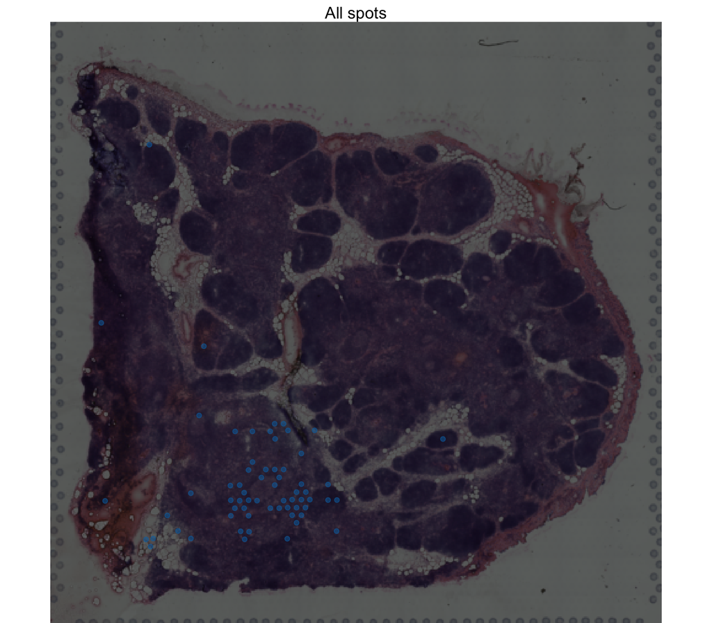

```r
# Everything below continues with mg_thymus_slice2_sirup, not neighbor_collapsed_sirup.
plotReceptors(
  mg_thymus_slice2_sirup,
  group = "sequence_alignment",
  group_val = "GAGGTGCCGCTGGTGCAGTCTGGAGCA...GAGGTGAAAAAGCCCGGGGAGTCTCTGAAGATCTCCTGTAAGGGTTCTGGATTCAGCTTT............ACCAGTTACTGGATCGGCTGGGTGCGCCAGATGCCCGGGAAAGGCCTGGAGTGGATGGGGATCATCTATCCTGGT......GACTCTGATACCAGATACAGCCCGTCCTTCCAA...GGCCAGGTCACCATCTCAGCCGACAAGTCCATCAACACCGCCTACCTGCAGTGGAGCAGCCTGAAGGCCTCGGACACCGCCATGTATTACTGTGCAAGAGTTACAAGTTCGGGTCTGGACACGTTCGACCTCGATTTCGACCCCTGGGGCCAGGGAACCCTGGTCACCGTCTCCTCAG",
  colors = "#0072B2",
  receptor_size = 1.5,
  receptor_alpha = 0.5,
  title = "All spots",
  show_receptor_legend = FALSE
)
```

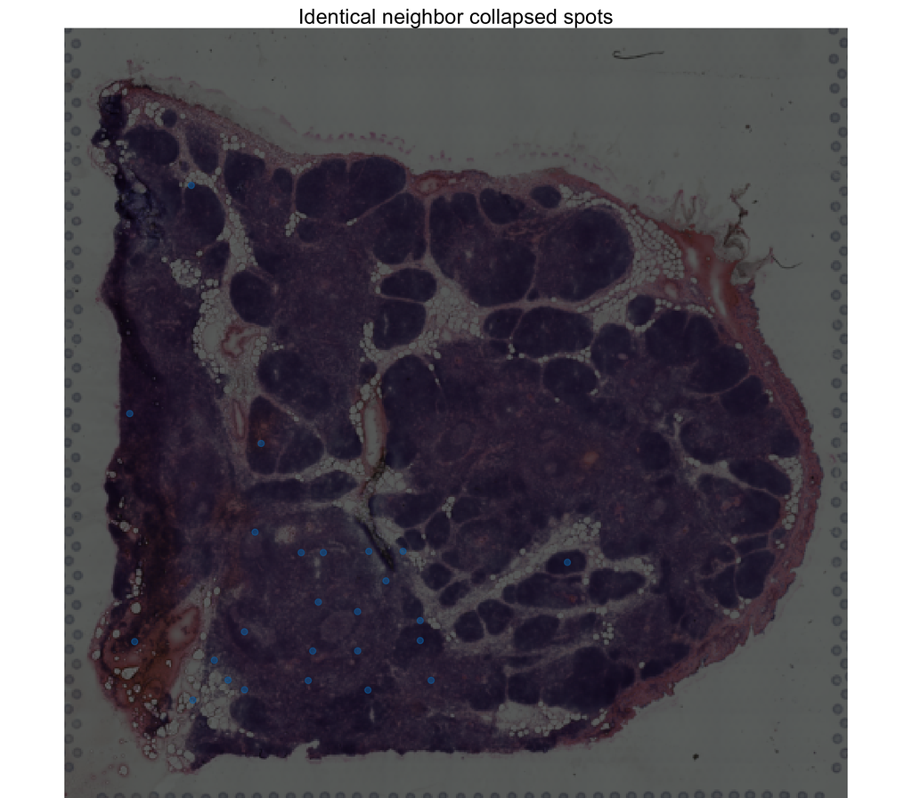

```r
plotReceptors(
  neighbor_collapsed_sirup,
  group = "sequence_alignment",
  group_val = "GAGGTGCCGCTGGTGCAGTCTGGAGCA...GAGGTGAAAAAGCCCGGGGAGTCTCTGAAGATCTCCTGTAAGGGTTCTGGATTCAGCTTT............ACCAGTTACTGGATCGGCTGGGTGCGCCAGATGCCCGGGAAAGGCCTGGAGTGGATGGGGATCATCTATCCTGGT......GACTCTGATACCAGATACAGCCCGTCCTTCCAA...GGCCAGGTCACCATCTCAGCCGACAAGTCCATCAACACCGCCTACCTGCAGTGGAGCAGCCTGAAGGCCTCGGACACCGCCATGTATTACTGTGCAAGAGTTACAAGTTCGGGTCTGGACACGTTCGACCTCGATTTCGACCCCTGGGGCCAGGGAACCCTGGTCACCGTCTCCTCAG",
  colors = "#0072B2",
  receptor_size = 1.5,
  receptor_alpha = 0.5,
  title = "Identical neighbor collapsed spots",
  show_receptor_legend = FALSE
)
```

# 6 Build BCR clones

I made functions that allow us to use external functions (i.e., dowser, seurat stuff) that interact with the spatial or receptors slot in a SIRUP object. `getReceptors()` returns the receptor table when we just want a function result, and `updateReceptors()` sticks the result back into the SIRUP object’s receptors slot. `updateReceptors()` takes all additional arguments used for the function that we’re calling. For example, if we want to build clones using the receptor sequences in the SIRUP object, we could do this:

```r
sample_only_clones <- scoper::hierarchicalClones(
  getReceptors(mg_thymus_slice2_sirup),
  threshold = 0.1,
  summarize_clones = FALSE,
  nproc = nproc
)
```

```
## Running defineClonesScoper in bulk mode and only keep heavy chains
```

```r
mg_thymus_slice2_sirup <- updateReceptors(
  mg_thymus_slice2_sirup,
  scoper::hierarchicalClones,
  threshold = 0.1,
  summarize_clones = FALSE,
  nproc = nproc
)
```

```
## Running defineClonesScoper in bulk mode and only keep heavy chains
```

Note that updateReceptors automatically updates the SIRUP metadata with the clone column name (if it’s clone_id), and otherwise we can pass `receptor_fields = list(clone = "new_clone")` to `updateReceptors` and it’ll update the metadata accordingly.

# 7 Plot expression and BCRs

We use `spatialExpressionPlot()` to plot gene expression and `plotReceptors()` to plot BCRs/TCRs.

`spatialExpressionPlot()` takes the SIRUP object (or the spatial seurat object) (`object`), the features to plot (`features`) (if length(features) > 1, then the function will return a list or patchwork of plots instead of just one), an assay (`assay`) and layer (`layer`) and images (`images` - usually leave as null because we’re just doing one image at a time). Because we stored `image_scale` and `swap_coords` in `mg_thymus_slice2_sirup`, the plot functions pull those settings from the SIRUP object; we would only pass them explicitly if we were using a raw Seurat object instead. Other arguments include feature colors (`feature_colors` - first entry is low color second is high), the zero tolerance - the value at which expression below is called 0 and isn’t shown in the plot (`zero_tol`), `point_size` and `point_alpha`, whether or not we want points with highest expression on top (`order_points` - default TRUE), `image_alpha`, `zoom` (default FALSE) which refers to whether or not we want to zoom in the spatial plot to focus on the nonzero regions only, `combine` (default TRUE) which will make it so that multiple plots are combined if the number of features images is > 1, and `title` (default NULL) which sets a title for the one/many plots.

We can also plot multiple genes’ expression at the same time with `spatialExpressionBlendPlot()` and `spatialExpressionMultiPlot()` (see below).

Lastly, `plotReceptorsExpression()` is a combination of `plotReceptors()` and `spatialExpressionPlot()`, so it takes basically all of the arguments from both functions. The output is a spatial expression plot with hollow rings around spots with positive receptor expression.

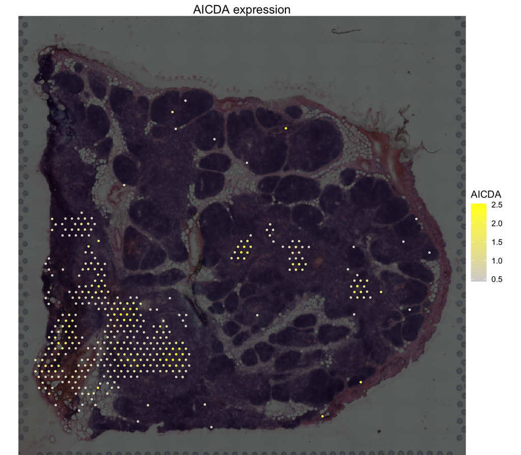

```r
gex_plot <- spatialExpressionPlot(
  mg_thymus_slice2_sirup,
  features = "AICDA",
  assay = "alra",
  layer = "data",
  title = "AICDA expression"
)
gex_plot
```

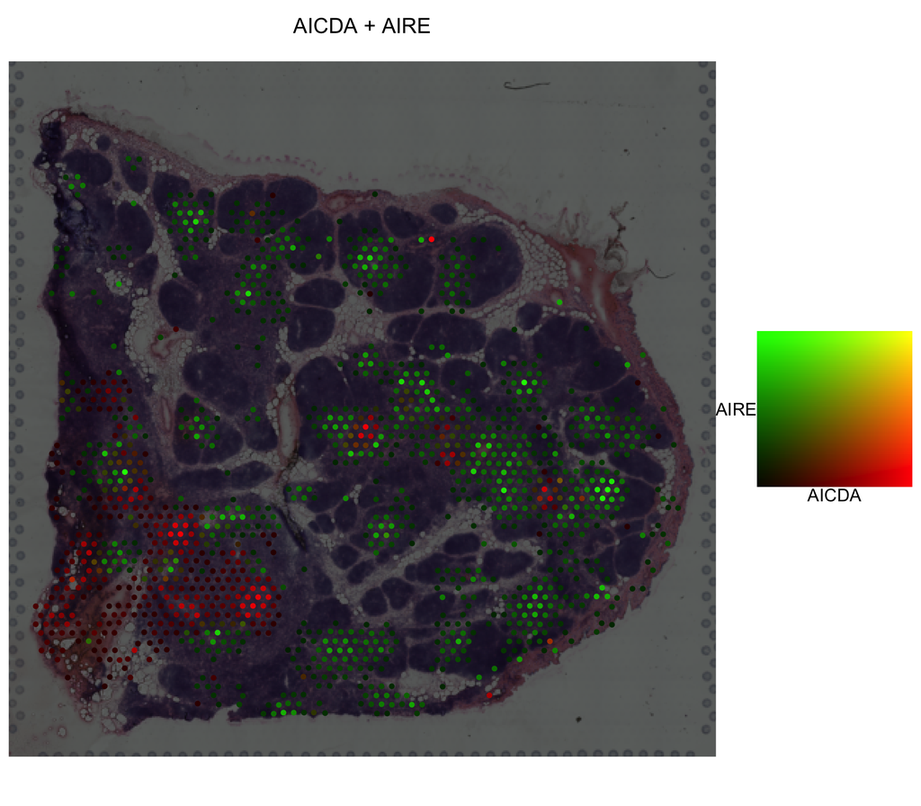

```r
features <- c("AICDA", "AIRE")
blend_plot <- spatialExpressionBlendPlot(
  mg_thymus_slice2_sirup,
  features = features,
  assay = "alra",
  layer = "data",
  point_size = 1,
  bottom_left = "#000000", # colors
  bottom_right = "#FF0000",
  top_left = "#00FF00",
  top_right = "#FFFF00",
  only_blended = TRUE #if false shows individual plots of gex too
)
blend_plot
```

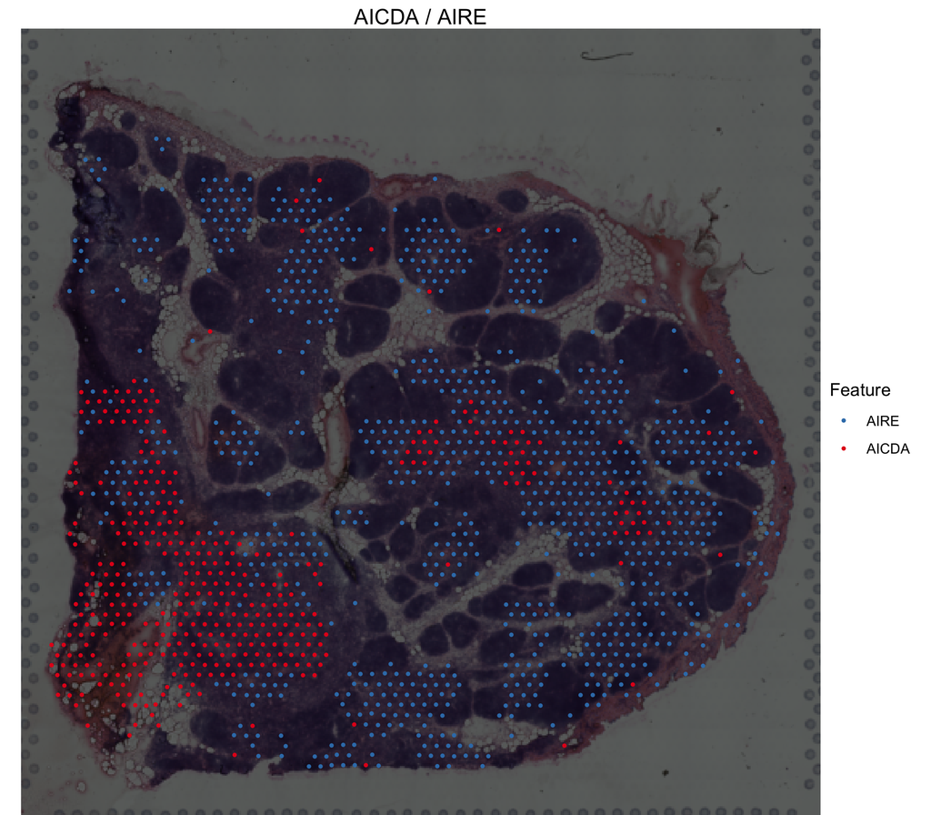

```r
multi_plot <- spatialExpressionMultiPlot(
  mg_thymus_slice2_sirup,
  features = features,
  assay = "alra",
  layer = "data",
  point_size = 0.6
)
multi_plot
```

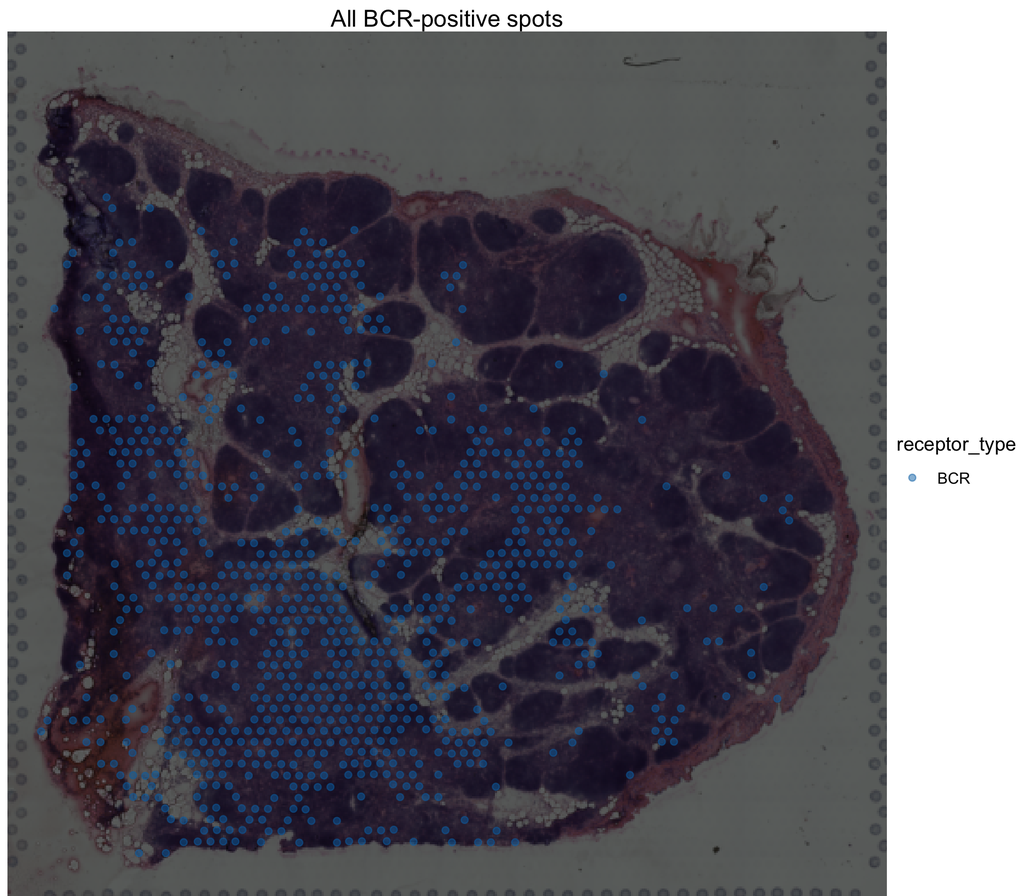

```r
all_bcr_plot <- plotReceptors(
  mg_thymus_slice2_sirup,
  group = "receptor_type",
  group_val = "BCR",
  colors = "#0072B2",
  receptor_size = 1.5,
  receptor_alpha = 0.5,
  title = "All BCR-positive spots"
)
all_bcr_plot
```

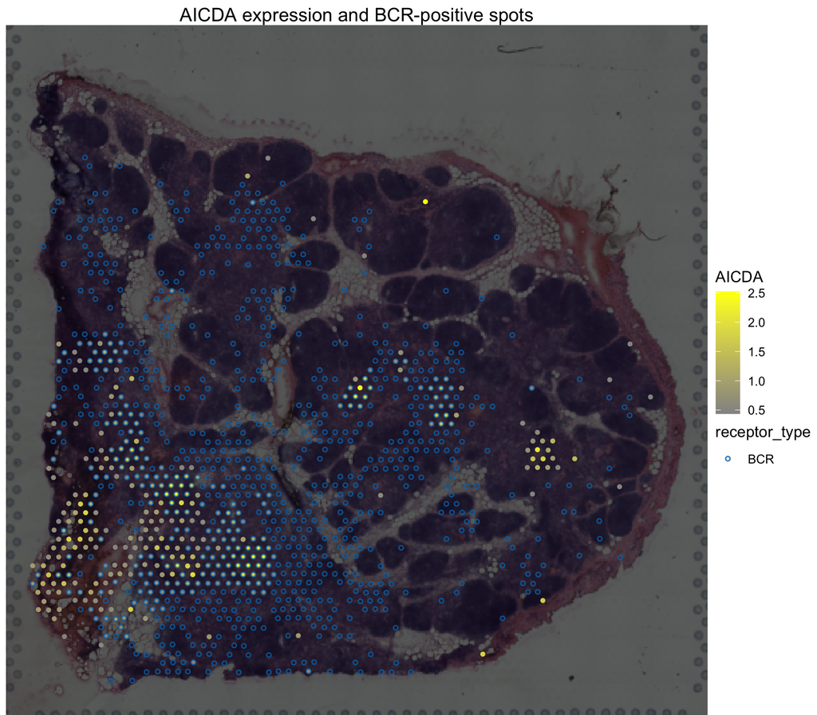

```r
gex_bcr_plot <- plotReceptorsExpression(
  mg_thymus_slice2_sirup,
  group = "receptor_type",
  group_val = "BCR",
  feature = "AICDA",
  assay = "alra",
  layer = "data",
  colors = "#0072B2",
  receptor_alpha = 0.8,
  title = "AICDA expression and BCR-positive spots"
)
gex_bcr_plot
```

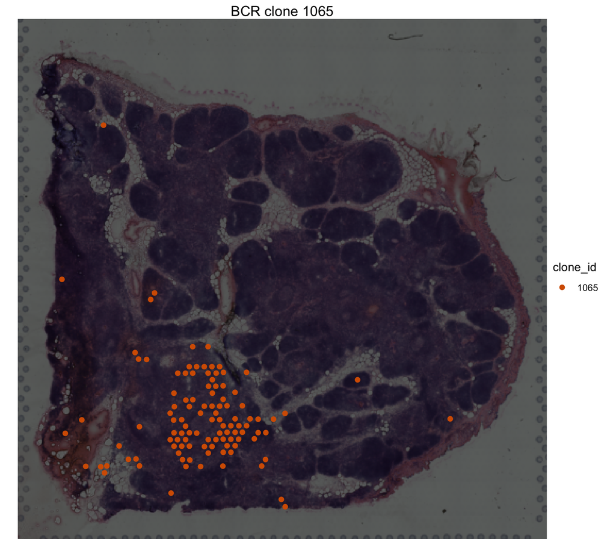

```r
demo_clone_id <- "1065" # one of bigger clones
clone_plot <- plotReceptors(
  mg_thymus_slice2_sirup,
  group = "clone_id",
  group_val = demo_clone_id,
  colors = "#D55E00",
  receptor_size = 1.8,
  title = paste("BCR clone", demo_clone_id)
)
clone_plot
```

# 8 Add an analysis to the SIRUP object - cell-type deconvolution

Add the cell2location cell-type deconvolution results from the Figure 3 analysis to the SIRUP object. Here I use the normalized proportion table, which has one row per spatial ID and one column per cell type.

```r
cell2location_path <- file.path(
  thymus_dir,
  "cell2location_analysis/results/thymus_slice2/cell2location_proportions.csv"
)

cell2location_proportions <- read.csv(
  cell2location_path,
  check.names = FALSE,
  stringsAsFactors = FALSE
)

# Need it in the right format to addMetaData
rownames(cell2location_proportions) <- cell2location_proportions$barcode
cell2location_proportions$barcode <- NULL
cell2location_proportions <- cell2location_proportions[
  colnames(getSpatial(mg_thymus_slice2_sirup)),
  ,
  drop = FALSE
]

# Use update spatial to add the cell type proportions to the sirup object
mg_thymus_slice2_sirup <- updateSpatial(
  mg_thymus_slice2_sirup,
  SeuratObject::AddMetaData,
  metadata = cell2location_proportions
)

getSpatial(mg_thymus_slice2_sirup)@meta.data %>%
  select(`GC B`, Tfh, `Conventional CD4`, `Naive/activated B`) %>%
  summary()
```

```
##       GC B               Tfh           Conventional CD4   Naive/activated B
##  Min.   :0.003594   Min.   :0.002997   Min.   :0.003329   Min.   :0.003783
##  1st Qu.:0.020866   1st Qu.:0.029540   1st Qu.:0.059690   1st Qu.:0.078628
##  Median :0.033377   Median :0.054080   Median :0.136608   Median :0.167760
##  Mean   :0.039363   Mean   :0.056722   Mean   :0.142169   Mean   :0.179441
##  3rd Qu.:0.048806   3rd Qu.:0.083074   3rd Qu.:0.213022   3rd Qu.:0.260238
##  Max.   :0.514292   Max.   :0.181812   Max.   :0.493577   Max.   :0.665132
```

# 9 (Global) Moran’s I and local Moran’s I

Recall that Moran’s I (aka global Moran’s I) is a measure of spatial autocorrelation, defined as
$$I\ =\
\frac{N}{S_0} \frac{\sum_{i=1}^{N} \sum_{j=1}^{N} w_{i,j}(x_i -
\bar{x})(x_j - \bar{x})} {\sum_{i=1}^{N} (x_i - \bar{x})^2}$$
, where $i,j$ index spatial locations, $N$ is the total number of locations, $S_0 = \sum_{i=1}^{N} \sum_{j=1}^{N} w_{i,j}$, $w_{i,j}$ is the weight for locations $i$ and $j$ - by default $w_{i,j} = 1$ if $i\sim j$ and is otherwise $0$. Moran’s I values range from -1 (perfect dispersion) to +1 (perfect correlation), with 0 indicating a random spatial pattern.

Local Moran’s I, often referred to as LISA (local indicators of spatial association) offers a local measure of spatial autocorrelation.
$$I_i\ =\ \frac{x_i - \bar{x}}{m}
\sum_{j=1}^N (x_j -\bar{x})$$
, where $m = \frac{\sum_{i=1}^{N} (x_i - \bar{x})^2}{N}$, and $j$ indexes the neighbors of $i$. Everything else is the same as for global Moran’s I. Also note that
$$I = \sum_{i=1}^{N}
\frac{I_i}{S_0}$$
, assuming the weights used are based on neighborhood.

Our `spatialMoran()` function computes Moran’s I for a given feature or metadata column in the sirup object. Arguments are `object` for the SIRUP object (or a spatial Seurat object), `variable` for the feature/clone/metadata/etc. to compute Moran’s I for, `variable_type`(`feature`, `metadata`, `receptor`, or `clone`) for the type of variable (we can compute Moran’s I for binary data, i.e., clone presence, but it’s suggested to examine a join count statistic instead), `value` is an optional argument used to specify a positive value (1) for converting a character variable (i.e., if we have variable = “sirup_receptor_type”, variable_type = “metadata”, value = “BCR” to set 1s in the spots where the value of sirup_receptor type = “BCR” and 0s in the spots where that isn’t the case), `barcode` and `clone` can be specified if needed, and if they aren’t then they get pulled from the sirup object (if possible), `layer` is the assay layer to use for features and `images` is the same if we have multiple images in the spatial object. The stored `image_scale` and `swap_coords` metadata are used for the spatial coordinates. `radius` is a distance by which to define neighbors for the weight in the Moran’s I calculation, if `radius` is not used, `k` is the number of nearest neighbors to use in a knn way, and `alternative` is the alternative hypothesis for the Moran’s I test. The function returns a list with `test`, which contains the Moran’s I statistic, expected value, variance, z-score, and p-value, `weights`, which contains the weight matrix used for the calculation `data`, `neighbors`, `radius`, `k`, and `variable`.

`spatialLocalMoran()` is the same, but it computes local Moran’s I for each spot and returns a dataframe that includes, among other things, the `local_i`, `expected_i`, `variance_i`, `z_i`, `p_value`, and `k` for each spot. It’s also better to plot in space with `plotSpatialLocalMoran()`.

```r
aicda_moran <- spatialMoran(
  mg_thymus_slice2_sirup,
  variable = "AICDA",
  variable_type = "feature",
  layer = "data",
  k = 6
)
aicda_moran$test
```

```
##
##  Moran I test under randomisation
##
## data:  dat$value
## weights: listw
##
## Moran I statistic standard deviate = 72.363, p-value < 2.2e-16
## alternative hypothesis: greater
## sample estimates:
## Moran I statistic       Expectation          Variance
##      0.7281017237     -0.0003123048      0.0001013259
```

```r
mg_thymus_slice2_sirup <- setAnalysis(
  mg_thymus_slice2_sirup,
  "morans_i",
  list(AICDA = aicda_moran)
)
```

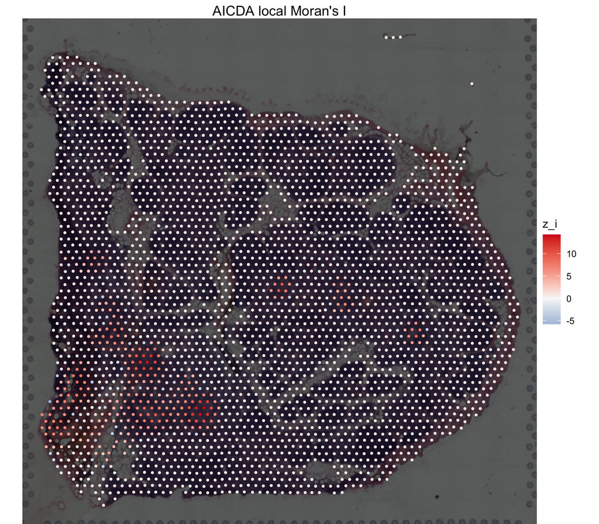

```r
aicda_local_moran <- spatialLocalMoran(
  mg_thymus_slice2_sirup,
  variable = "AICDA",
  variable_type = "feature",
  layer = "data",
  k = 6
)

mg_thymus_slice2_sirup <- setAnalysis(
  mg_thymus_slice2_sirup,
  "local_morans_i",
  list(AICDA = aicda_local_moran)
)

aicda_local_plot <- plotSpatialLocalMoran(
  mg_thymus_slice2_sirup,
  aicda_local_moran,
  title = "AICDA local Moran's I"
)

plot(aicda_local_plot)
```

# 10 Ripley’s cross K

Recall that Ripley’s cross K is a measure of spatial correlation for two distinct point types, call them type $A$ and type $B$.
$$K(r)\ =\
\frac{1}{N_A N_B} \sum_{i=1}^{N_A} \sum_{j = 1}^{N_B} I(d_{i,j} \leq
r)$$
, where $r$ refers to the length of a radius, $N_A$ is the total number of points of type $A$ in the population and $N_B$ is the total number of points of type $B$ in the population, $d_{i,j}$ is the distance between points $i$ and $j$, $I(d_{i,j} \leq r)$ is an indicator function that is 1 if the distance between points $i$ and $j$ is less than or equal to $r$ and 0 otherwise, and $A_i(r)$ is the area of the disc around point $i$. Essentially, this tells us if we see more points of type $B$ within a radius $r$ of points of type $A$ than we would expect by random chance.

Let’s say that a spot contains a cell type when its cell2location proportion is greater than 10%. Let’s find out if Tfh cells are significantly closer to GCBs than we would expect by chance at any given radius. Below we get points in the right format. It’s a bit weird when we have spots with multiple types, but the overlap is only two spots, so we’ll just ignore them.

```r
mg_thymus_slice2_sirup <- updateSpatial(
  mg_thymus_slice2_sirup,
  function(spatial) {
    spatial$gc_b_present <- spatial$`GC B` > 0.10
    spatial$tfh_present <- spatial$Tfh > 0.10
    spatial$ripley_gc_b_tfh_mark <- dplyr::case_when(
      spatial$gc_b_present & !spatial$tfh_present ~ "GC B > 10%",
      spatial$tfh_present & !spatial$gc_b_present ~ "Tfh > 10%",
      spatial$gc_b_present & spatial$tfh_present ~ "GC B > 10% and Tfh > 10%",
      TRUE ~ "none"
    )
    spatial
  }
)

table(
  getSpatial(mg_thymus_slice2_sirup)$ripley_gc_b_tfh_mark
)
```

```
##
##               GC B > 10% GC B > 10% and Tfh > 10%                     none
##                       80                        2                     2766
##                Tfh > 10%
##                      355
```

`spatialRipleyCrossK()` is the function to call Ripley’s K. It takes a SIRUP object (or spatial Seurat object) in `object`, the spatial metadata column that has the labels for the types (or marks) in `mark_col`, the two types to compare in `i` and `j`, the number of simulations to run in `nsim`, and the maximum radius to consider in `max_r`. We can also determine the cross K value for a specific radius by specifying `r`. The function works by setting the spatial window, setting up spatstat point processes with the x/y values and the marks, then running kcross and envelope from spatstat. It returns a list with the observed K, the simulated K (envelopes), data for plotting, etc.

We plot the results of Ripley’s cross K with `plotRipleyCrossK()`, which takes the Ripley’s cross K result list `kcross`, an optional plot title `title`, `observed_color` and `simulated_color` for the observed and simulated K values, `envelope_fill` and `envelope_alpha` for the confidence envelope fill color and alpha, `facet` (default TRUE) to facet the plot by image if multiple images are present (never the case for me), and `log_y` (default FALSE) to log-transform the y-axis.

```r
gc_b_tfh_k <- spatialRipleyCrossK(
  mg_thymus_slice2_sirup,
  mark_col = "ripley_gc_b_tfh_mark",
  i = "GC B > 10%",
  j = "Tfh > 10%",
  nsim = 99,
  max_r = 500
)
```

```
## Generating 99 simulations by evaluating expression  ...
## 1, 2, 3, 4, 5, 6, 7, 8, 9, 10, 11, 12, 13, 14, 15, 16, 17, 18, 19, 20,
## 21, 22, 23, 24, 25, 26, 27, 28, 29, 30, 31, 32, 33, 34, 35, 36, 37, 38, 39, 40,
## 41, 42, 43, 44, 45, 46, 47, 48, 49, 50, 51, 52, 53, 54, 55, 56, 57, 58, 59, 60,
## 61, 62, 63, 64, 65, 66, 67, 68, 69, 70, 71, 72, 73, 74, 75, 76, 77, 78, 79, 80,
## 81, 82, 83, 84, 85, 86, 87, 88, 89, 90, 91, 92, 93, 94, 95, 96, 97, 98,
## 99.
##
## Done.
```

```r
str(gc_b_tfh_k)
```

[output not shown]

[output cut: 38 more lines]

[output not shown]

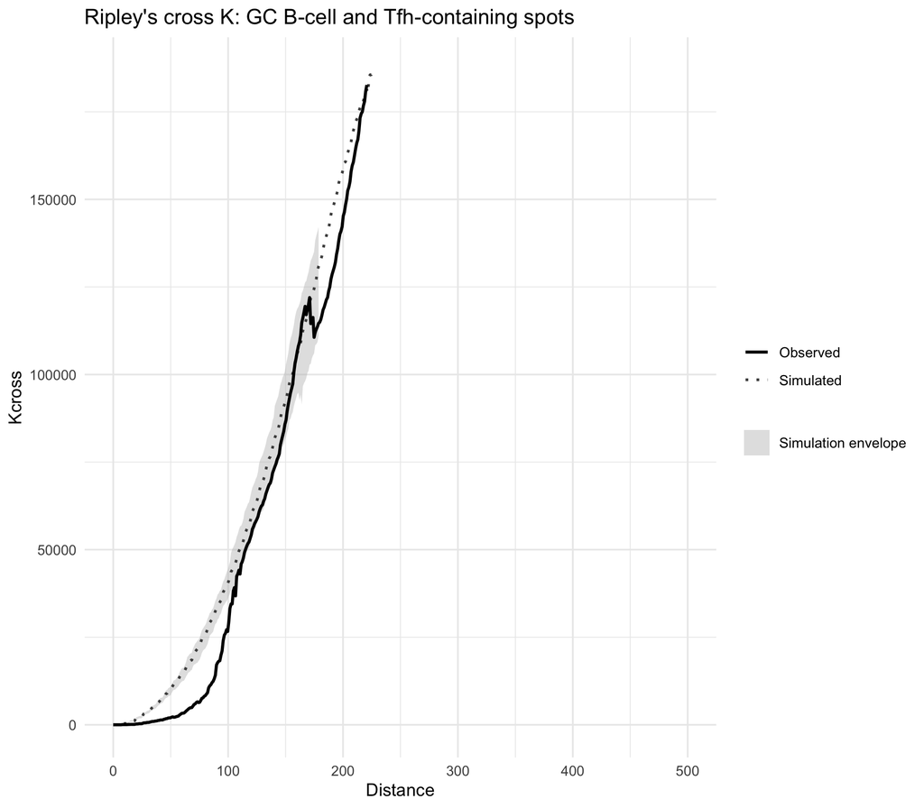

```r
mg_thymus_slice2_sirup <- setAnalysis(
  mg_thymus_slice2_sirup,
  "ripley_gc_b_tfh",
  gc_b_tfh_k
)

plotRipleyCrossK(
  getAnalysis(mg_thymus_slice2_sirup, "ripley_gc_b_tfh"),
  title = "Ripley's cross K: GC B-cell and Tfh-containing spots"
)
```

# 11 Join count for one B-cell clone

The join-count statistic examines spatial autocorrelation in binary or categorical data. It works by counting the number of neighboring pairs of spots that are both positive for a given clone. The null hypothesis is that the observed number of neighboring pairs is no different than what would be expected by chance. Pretty much all of the arguments are the same as in the Moran’s I functions, but we can restrict the join count analysis to a particular polygon (or set of polygons) if we want. The function returns a summary table `summary`, raw `spdep` tests `tests`, `data` if requested (return_data = TRUE), and `neighbors`, `weights`, `k`, the alternative hypothesis `alternative`, and the minimum number of barcodes a clone needs to be found in to be tested (can run this on multiple clones at once) `min_spatial_ids`. Be sure to return the data if we want to plot the results with `plotSpatialCloneJoinCount()`. The plot shows all the locations with the clone and the observed and expected values of the statistic (just counts number of clone-clone neighbors).

```r
join_count_clone_id <- "1065"

clone_join_count <- spatialCloneJoinCount(
  object = mg_thymus_slice2_sirup,
  clone_val = join_count_clone_id,
  min_spatial_ids = 3,
  k = 6,
  alternative = "greater",
  return_data = TRUE
)
clone_join_count$summary
```

```
##   clone_id  image polygon n_spatial_ids n_clone_spatial_ids observed_join_count
## 1     1065 slice1       2            11                   4                   2
##   expected_join_count  variance statistic   p_value
## 1                 3.6 0.9672727 -1.626843 0.9481147
##                                   method radius k alternative
## 1 Join count test under nonfree sampling     NA 6     greater
```

```r
mg_thymus_slice2_sirup <- setAnalysis(
  mg_thymus_slice2_sirup,
  "clone_join_count",
  clone_join_count
)

# getAnalysis() can inspect or summarize a stored result without removing it.
getAnalysis(mg_thymus_slice2_sirup, "clone_join_count")$summary
```

```
##   clone_id  image polygon n_spatial_ids n_clone_spatial_ids observed_join_count
## 1     1065 slice1       2            11                   4                   2
##   expected_join_count  variance statistic   p_value
## 1                 3.6 0.9672727 -1.626843 0.9481147
##                                   method radius k alternative
## 1 Join count test under nonfree sampling     NA 6     greater
```

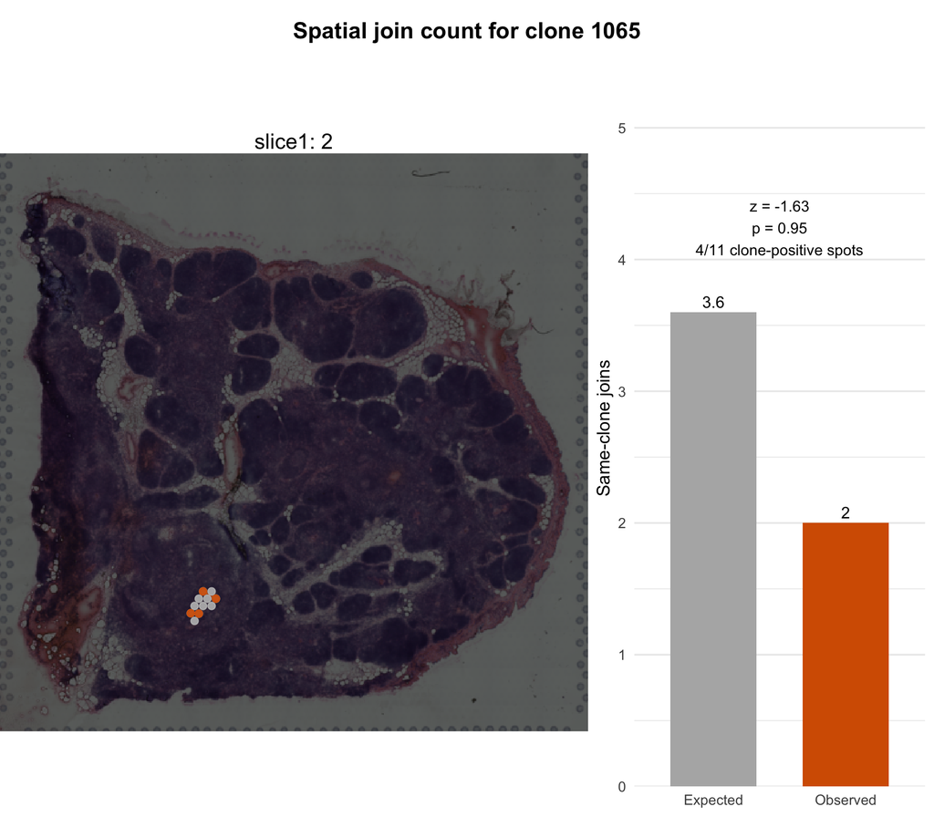

```r
plotSpatialCloneJoinCount(
  join_count = clone_join_count,
  object = mg_thymus_slice2_sirup,
  clone_val = join_count_clone_id,
  show_neighbors = TRUE
)
```

# 12 Select or load GC polygons

The `selectSpatialPolygons()` function takes a SIRUP object `object`, an `assay` and `layer` to use for plotting, a `feature` to show on the plot (i.e., AICDA, default is NA and just shows black dots), a save path to save the polygon vertices, and arguments for the Rshiny app (`host`, `port`, `plot_image`, `launch_browser`). The function returns a vertex table.

`selectSpatialPolygons()` will build the Shiny app for drawing region boundaries using a SIRUP object (or spatial seurat object). At a high level, it pulls the tissue coordinates from the object, using the `image_scale` and `swap_coords` metadata stored in the SIRUP object, and opens a clickable plot of the spots. The spots are colored by a `feature`, we optionally show the histology image underneath with `plot_image`, adjust point size/opacity, and then click around the boundary of a region. Each click is snapped to the nearest actual spatial ID. As you click, the function records the selected spatial ID, x/y coordinates, polygon ID, and image name. `Close polygon` repeats the first point at the end of the current polygon, `New polygon` closes the current one and starts another region, and the `remove/reset` buttons let you fix mistakes by removing the last point or fully resetting. When you hit `Done`, it closes any open polygon, returns a vertex table, and optionally writes that table to CSV if save_path is provided.

We then attach that geometry to the SIRUP object with `addPolygons()`. `addPolygons()` will automatically annotate which polygon each spatial barcode is in, both in the metadata of the spatial Seurat object and in the receptor table, Once attached, downstream polygon-aware functions can use the stored geometry directly without passing the same vertex table repeatedly.

We then plot the polygons with `plotSpatialPolygons()`, which can just plot the polygons by taking a sirup object `object` with attached polygons (or we can specify polygon(s) with `polygon`).

```r
if (!file.exists(polygon_path)) {
  mg_thymus_slice2_polygons <- selectSpatialPolygons(
    object = mg_thymus_slice2_sirup,
    assay = "alra",
    layer = "data",
    feature = "AICDA",
    save_path = polygon_path,
    host = "0.0.0.0",
    port = 8788L,
    plot_image = TRUE,
    launch_browser = TRUE
  )
} else {
  mg_thymus_slice2_polygons <- read.csv(
    polygon_path
  )
}
mg_thymus_slice2_sirup <- addPolygons(
  mg_thymus_slice2_sirup,
  polygons = mg_thymus_slice2_polygons
)

# The object now owns the polygon geometry. The plotting function uses it when
# polygon is omitted, while getPolygons() provides the canonical table for
# inspection or export.
getPolygons(mg_thymus_slice2_sirup)
```

```
## # A tibble: 8 × 2
##   polygon_id vertices
##   <chr>      <named list>
## 1 1          <tibble [8 × 4]>
## 2 2          <tibble [9 × 4]>
## 3 3          <tibble [10 × 4]>
## 4 4          <tibble [8 × 4]>
## 5 5          <tibble [5 × 4]>
## 6 6          <tibble [6 × 4]>
## 7 7          <tibble [6 × 4]>
## 8 8          <tibble [7 × 4]>
```

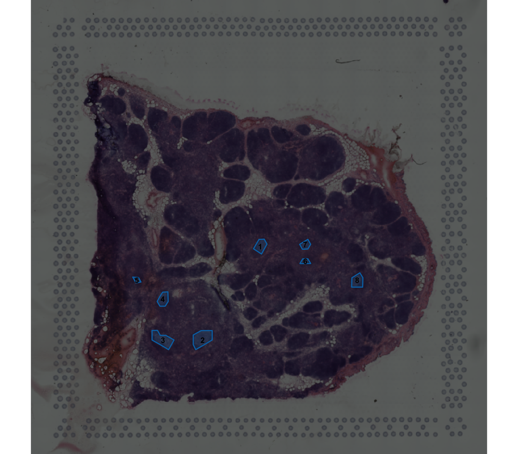

```r
plotSpatialPolygons(
  object = mg_thymus_slice2_sirup,
  polygon_alpha = 0.2
)
```

Because `addPolygons()` annotates both the receptor table and the spatial metadata, we can also immediately summarize the receptors in each polygon.

# 13 Working with polygons

`polygonReceptorSummary()` returns an updated SIRUP object and saves the summary as an analysis. By default, this will return n_receptors, n_spatial_ids, n_clones and top_clone_fraction (if `clone` argument is specified). We can also specify a `spatial_id` (default is NULL which pulls from the SIRUP object), `polygon_id` (default `polygon`, but if that’s not a column looks in the SIRUP object for polygons and uses “polygon_id”). Also takes `weight` (default NULL) which if specified will weight receptor rows in all analysis by the column (note that this can lead to weirdness for things like cat operations),

We can do additional summary operations with `summary_columns` (default NULL) which is a vector of columns to also summarize, `summary_operations` (default NULL) which is a vector of operations to perform on the summary columns (options are `count`, `sum`, `mean`, `median`, `variance`, `var`, `sd`, `min`, `max`, `any`, `all`, and `cat`), and `analysis_name` (default “polygon_receptor_summary”) which is the name of the analysis to store in the SIRUP object. The output columns from custom summaries are named as `[operation]_[column]`, so `cat_locus` contains the observed receptor loci in each polygon.

```r
mg_thymus_slice2_sirup <- polygonReceptorSummary(
  mg_thymus_slice2_sirup,
  clone = "clone_id", # this is the default
  polygon_id = "polygon_id",
  summary_columns = c("locus", "junction_length"),
  summary_operations = c("cat", "mean")
)

getAnalysis(mg_thymus_slice2_sirup, "polygon_receptor_summary")
```

```
## # A tibble: 8 × 7
##   polygon_id n_receptors n_spatial_ids n_clones top_clone_fraction cat_locus
##   <chr>            <int>         <int>    <int>              <dbl> <chr>
## 1 1                   26             5       17              0.115 IGH
## 2 2                   75            11       25              0.16  IGH
## 3 3                   12             5        6              0.417 IGH
## 4 4                   33             6       12              0.212 IGH
## 5 5                    9             3        5              0.444 IGH
## 6 6                   12             1        7              0.333 IGH
## 7 7                   17             3        9              0.235 IGH
## 8 8                    0             0        0             NA     <NA>
## # ℹ 1 more variable: mean_junction_length <dbl>
```

If we want to run something more custom, `withPolygons()` splits the receptor table by polygon and applies a function to each polygon’s rows. For instance, if I wanted to do baseline to get selection pressure for sequences in each polygon, this is how we could do it. That’s too much so we don’t do it here.

```r
withPolygons(
  mg_thymus_slice2_sirup,
  function(receptors) {
    receptors %>%
      count(locus, name = "n_receptors")
  }
)
```

```
## $`1`
## # A tibble: 1 × 2
##   locus n_receptors
##   <chr>       <int>
## 1 IGH            26
##
## $`2`
## # A tibble: 1 × 2
##   locus n_receptors
##   <chr>       <int>
## 1 IGH            75
##
## $`3`
## # A tibble: 1 × 2
##   locus n_receptors
##   <chr>       <int>
## 1 IGH            12
##
## $`4`
## # A tibble: 1 × 2
##   locus n_receptors
##   <chr>       <int>
## 1 IGH            33
##
## $`5`
## # A tibble: 1 × 2
##   locus n_receptors
##   <chr>       <int>
## 1 IGH             9
##
## $`6`
## # A tibble: 1 × 2
##   locus n_receptors
##   <chr>       <int>
## 1 IGH            12
##
## $`7`
## # A tibble: 1 × 2
##   locus n_receptors
##   <chr>       <int>
## 1 IGH            17
##
## $`8`
## # A tibble: 0 × 2
## # ℹ 2 variables: locus <chr>, n_receptors <int>
```

I recently added support for more complex polygons, including overlapping or nested polygons. We do more selection below using `selectSpatialPolygons()` on a weird polygon setup. When we add polygons to a SIRUP object, we now add more information. There’s a simplified `polygon_id` column that picks a single region. If a barcode is inside more than one polygon, it is assigned to the smallest matching polygon by area for the `polygon_id`. Then, we have boolean columns for each individual polygon `polygon_<polygon_ID>` to keep the full membership information, so nested or overlapping regions can be recombined later if we want a different primary label. The polygon analyses use the single `polygon_id` column, not the boolean membership columns; if we want analyses to use a different overlap rule, we can make a new `polygon_id` column from those flags first.

```r
if (file.exists(complex_polygon_path)) {
  mg_thymus_slice2_complex_polygons <- read.csv(
    complex_polygon_path,
    stringsAsFactors = FALSE,
    check.names = FALSE
  )
} else {
  mg_thymus_slice2_complex_polygons <- selectSpatialPolygons(
    object = mg_thymus_slice2_sirup,
    assay = "alra",
    layer = "data",
    feature = NA, #default is NA, doesn't show gex
    save_path = complex_polygon_path,
    host = "0.0.0.0",
    port = 8789L,
    plot_image = TRUE,
    launch_browser = TRUE
  )
}
mg_thymus_slice2_sirup_complex <- mg_thymus_slice2_sirup %>%
  addPolygons(
    polygons_path = complex_polygon_path
  )

mg_thymus_slice2_sirup_complex$receptors %>%
  filter(!is.na(polygon_id)) %>%
  filter((polygon_2 | polygon_3)) %>%
  select(polygon_id, polygon_1, polygon_2, polygon_3) %>%
  head(15) %>% print(n=15)
```

```
## # A tibble: 15 × 4
##    polygon_id polygon_1 polygon_2 polygon_3
##    <chr>      <lgl>     <lgl>     <lgl>
##  1 3          TRUE      FALSE     TRUE
##  2 3          TRUE      FALSE     TRUE
##  3 3          TRUE      FALSE     TRUE
##  4 3          TRUE      FALSE     TRUE
##  5 3          TRUE      FALSE     TRUE
##  6 3          TRUE      FALSE     TRUE
##  7 3          TRUE      FALSE     TRUE
##  8 3          TRUE      FALSE     TRUE
##  9 3          TRUE      FALSE     TRUE
## 10 3          TRUE      FALSE     TRUE
## 11 3          TRUE      FALSE     TRUE
## 12 3          FALSE     FALSE     TRUE
## 13 3          TRUE      FALSE     TRUE
## 14 3          FALSE     FALSE     TRUE
## 15 3          TRUE      FALSE     TRUE
```

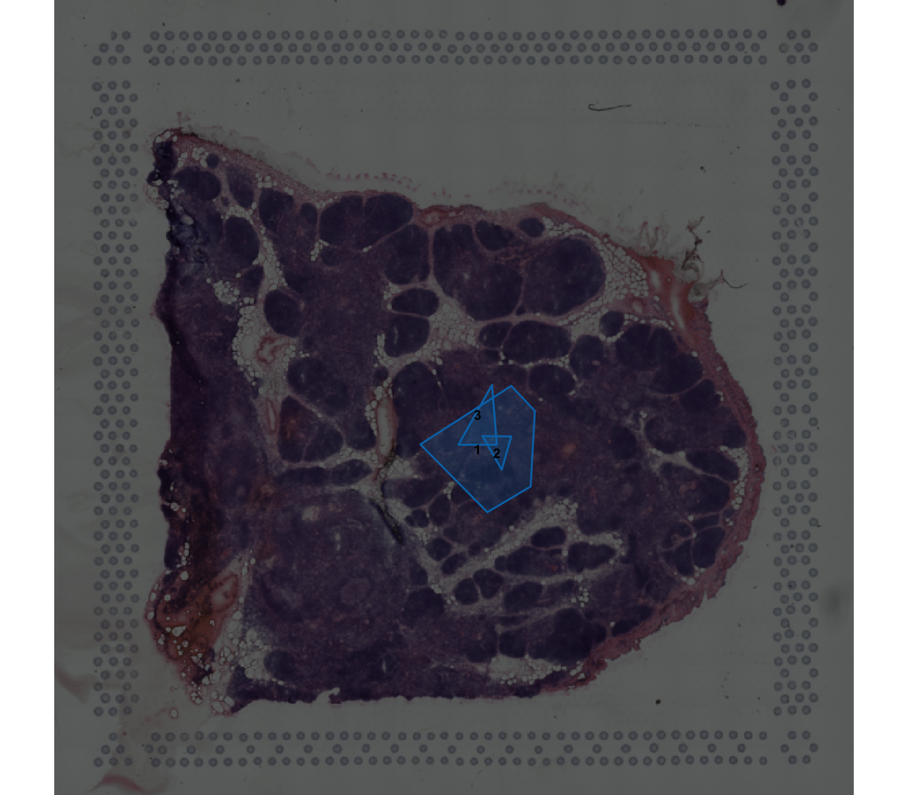

```r
plotSpatialPolygons(
  object = mg_thymus_slice2_sirup_complex,
  polygon_alpha = 0.2
)
```

## 13.1 Clonal abundance and diversity within polygons

For clonal abundance and diversity, we can also estimate curves separately for each polygon using `polygonAbundance()` and `polygonDiversity()` which are wrappers for `alakazam` functions `estimateAbundance()` and `alphaDiversity()`. Arguments to both are the SIRUP object or airr table `receptors`, `polygons` (default NULL, which pulls from the SIRUP object), `polygon_id` (default “polygon”), `mode` (by_polygon or all_polygons) which determines whether to do this by polygons separately or using all receptors in any polygon, and `analysis_name` (default polygon_abundance) which sets the name of the analysis to save. Other arguments are directly from the `alakazam` functions. Polygons below the requested `min_n` threshold return `NULL`. Once the diversity curves are stored, `summarizePolygonDiversity()` pulls out a single `q` value into a polygon-level table, which is handy if we want to map something like Simpson diversity (`q = 2`) back onto polygons.

`plotSpatialPolygons()`, which we saw earlier just show where the polygons were, can also color the stored GC polygons by a column in a stored analysis. Numeric columns use `scale_fill_gradient()` with the default `analysis_fill = c("#D3D3D3", "#FFFF00")`; the two colors can be changed when the metric needs a different range. Categorical columns use the Glasbey palette. Polygons without a matching summary value are shown in grey. `polygon_fill` and `polygon_color` control the solid fill and outline when no analysis column is supplied.

```r
mg_thymus_slice2_sirup <- mg_thymus_slice2_sirup %>%
  polygonAbundance(min_n = 5) %>%
  polygonDiversity(min_n = 5, max_q = 3, step_q = 0.1) %>%
  summarizePolygonDiversity(q = 2, analysis_name = "polygon_simpson_diversity")

getAnalysis(mg_thymus_slice2_sirup, "polygon_simpson_diversity")

plotSpatialPolygons(
  object = mg_thymus_slice2_sirup,
  fill_analysis = "polygon_simpson_diversity",
  fill_column = "d",
  polygon_alpha = 1,
  polygon_color = "white",
  label = TRUE
) + labs(title = "Polygon-level Simpson diversity (q=2)")
```

[output not shown]

# 14 Clonal dominance

One of the really interesting things we can do with spatially resolved BCR/TCR data is examine which clones dominate particular regions. We do this with `spatialCloneDominance()`, which determines which clones are in which polygon and what proportion they make up. For each polygon, it sums receptor counts by clone, calculates each clone’s proportion of the regional receptor total, attaches optional V-gene/family/superfamily summaries, and returns a list with the summary table and the underlying regional spatial IDs, coordinates, BCRs/TCRs included, polygon vertices, and metadata needed for downstream plotting functions.

We pass the function a SIRUP object in `object`. We can pass polygons to `polygon` if we’re using a spatial Seurat object or we haven’t added polygons to the SIRUP object, but we don’t need to if we’ve run `addPolygons()`. If we only want to use particular polygons, we can pass those IDs to `polygon_val`, `clone`, `locus`, `count`, and `v_call` are all arguments to point to those columns in the spAIRR data. If `count` is NULL (which it is by default), each receptor row counts once. `locus` restricts the analysis to specific receptor loci, and `exclude_singletons` removes singleton clones. `images` can restrict which spatial image is used, while `image_scale` and `swap_coords` can be specified but are automatically pulled from the SIRUP object metadata here. `include_boundary` is set when we add polygons to the SIRUP object with `addPolygons()` and determines whether spots exactly on polygon boundaries are treated as inside or outside. If a polygon is not already closed, SIRUP closes it automatically by repeating the first vertex. The same result can also be stored in the SIRUP object’s `analyses` slot.

The clonal dominance object is a list with a few different pieces:

- `dominance`: the main summary table, one row per clone/polygon combination and columns describing receptor counts, clone proportions, and optional V-gene summaries.
- `region_spatial_ids`: the spatial IDs that were inside each polygon.
- `region_coordinates`: the spatial coordinates for the spots inside each polygon.
- `region_receptors`: the receptor data that matched spatial IDs inside each polygon, with xx/y coordinates and polygon IDs.
- `polygons`: the polygon IDs and vertices (used in plotting downstream).
- `metadata`: the receptor columns used for the calculation, such as the spatial ID, clone, locus, count, and V-call columns.

```r
gc_clonal_dominance <- spatialCloneDominance(
  object = mg_thymus_slice2_sirup,
  locus_val = "IGH",
  exclude_singletons = TRUE
)

mg_thymus_slice2_sirup <- setAnalysis(
  mg_thymus_slice2_sirup,
  "gc_clonal_dominance",
  gc_clonal_dominance
)

mg_thymus_slice2_sirup <- updateAnalysis(
  mg_thymus_slice2_sirup,
  "gc_clonal_dominance",
  function(result, sample_id) {
    result$metadata$sample_id <- sample_id
    result
  },
  sample_id = sample_id
)

getAnalysis(mg_thymus_slice2_sirup, "gc_clonal_dominance")$dominance %>%
  arrange(polygon, desc(proportion)) %>%
  group_by(polygon) %>%
  slice_head(n = 5)
```

```
## # A tibble: 33 × 10
## # Groups:   polygon [7]
##    clone_id v_gene       v_gene_family v_gene_superfamily n_receptors proportion
##    <chr>    <chr>        <chr>         <chr>                    <dbl>      <dbl>
##  1 249      IGHV4-59*01… IGHV4-59      IGHV4                       29     0.337
##  2 193      IGHV3-21*01… IGHV3-21      IGHV3                       13     0.151
##  3 420      IGHV3-33*01… IGHV3-33      IGHV3                       11     0.128
##  4 965      IGHV4-34*01  IGHV4-34      IGHV4                        8     0.0930
##  5 394      IGHV4-61*01  IGHV4-61      IGHV4                        6     0.0698
##  6 798      IGHV1-24*01  IGHV1-24      IGHV1                       37     0.117
##  7 1011     IGHV4-59*01… IGHV4-59,IGH… IGHV4                       33     0.104
##  8 472      IGHV3-30-3*… IGHV3-30,IGH… IGHV3                       31     0.0978
##  9 1003     IGHV4-59*12… IGHV4-59,IGH… IGHV4                       29     0.0915
## 10 1065     IGHV5-51*01  IGHV5-51      IGHV5                       28     0.0883
## # ℹ 23 more rows
## # ℹ 4 more variables: region_receptor_total <dbl>, n_region_spatial_ids <int>,
## #   locus_filter <chr>, polygon <chr>
```

```r
str(gc_clonal_dominance)
```

[output not shown]

[output cut: 54 more lines]

```
##   ..$ v_gene_family     : chr [1:166] "IGHV3-21" "IGHV3-21" "IGHV4-59" "IGHV4-59" ...
##   ..$ v_gene_superfamily: chr [1:166] "IGHV3" "IGHV3" "IGHV4" "IGHV4" ...
##  $ polygons          :'data.frame':  59 obs. of  4 variables:
##   ..$ x       : num [1:59] 307 310 307 303 293 ...
##   ..$ y       : num [1:59] 314 320 327 333 327 ...
##   ..$ polygon : chr [1:59] "1" "1" "1" "1" ...
##   ..$ .sirup_y: num [1:59] -314 -320 -327 -333 -327 ...
##  $ metadata          :List of 1
##   ..$ receptor_fields:List of 5
##   .. ..$ spatial_id: chr "barcode_10x"
##   .. ..$ clone     : chr "clone_id"
##   .. ..$ locus     : chr "locus"
##   .. ..$ count     : chr "consensus_count"
##   .. ..$ v_call    : chr "v_call"
##  - attr(*, "class")= chr [1:2] "sirup_spatial_clone_dominance" "list"
```

We can then plot the receptor-level dominance results. The receptor-point and pie functions below require the dominance result (`dominance`) and the SIRUP object (`object`). `plotSpatialRegionReceptors()` just plots a scatter plot with points colored to represent the top n (`top_n`) most present values in the `color` column. The coordinate scale and orientation still come from the SIRUP object metadata. Other arguments include `polygon_id` to restrict the plot to a particular polygon, `point_size`, `point_alpha`, `polygon_alpha`, `polygon_color`, `polygon_fill`, and `image_alpha`, all of which are self-explanatory. Lastly, we have `other_label` to determine what to call the points that don’t fit into the `top_n` categories of `color`, `other_color` for their color, `plot_other` for whether or not we want to plot them, `zoom` (default FALSE) in case we want to zoom in on where we have points instead of looking at the whole tissue, and `combine` if we want to combine separate plots if we have multiple images in our object.

`plotSpatialPolygonPies()` is a cooler function that allows us to highlight the polygons and then either have pie charts to the side that show dominance with `mode`=“side-by-side”, or clip the pie charts into the polygons with `mode`=“spatial_clipped”. The arguments are the same as in `plotSpatialRegionReceptors()`, but we also have `fill` (instead of `color`) to determine what to fill the pie charts with, `label_top_n` to determine how many of the top values in `fill` to label (things can get messy if this is too high), and `label_size` to determine the size of those labels. `pies_per_page` defaults to 6, and that controls how many pie charts are shown per page in the side-by-side mode. If we have more than `pies_per_page`, we loop onto a second page. We also have `spatial_legend` (default FALSE) which shows a shared fill legend for `spatial_clipped` pie plots. This is super messy so I don’t really recommend it. Honestly, the side-by-side plots are a more useful visual, but the spatial_clipped plots are super fun. Both were pretty annoying to make.

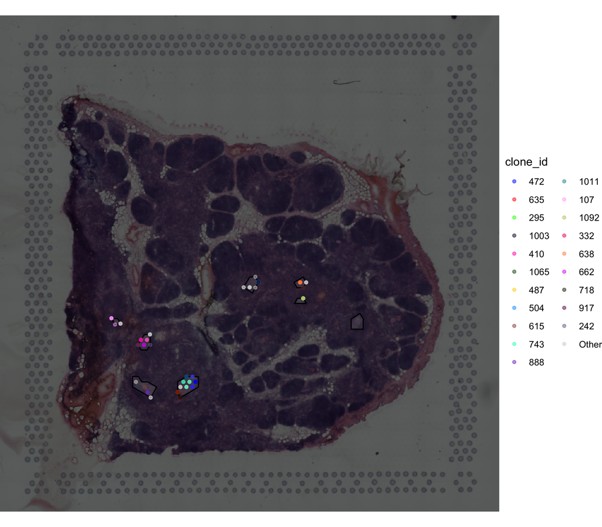

```r
gc_clone_plot <- plotSpatialRegionReceptors(
  dominance = gc_clonal_dominance,
  object = mg_thymus_slice2_sirup,
  color = "clone_id",
  top_n = 20,
  point_size = 1.2,
  polygon_alpha = 0.08
)

gc_v_gene_plot <- plotSpatialRegionReceptors(
  dominance = gc_clonal_dominance,
  object = mg_thymus_slice2_sirup,
  color = "v_gene_superfamily",
  top_n = 20,
  point_size = 1.2,
  polygon_alpha = 0.08
)

gc_clone_plot
```

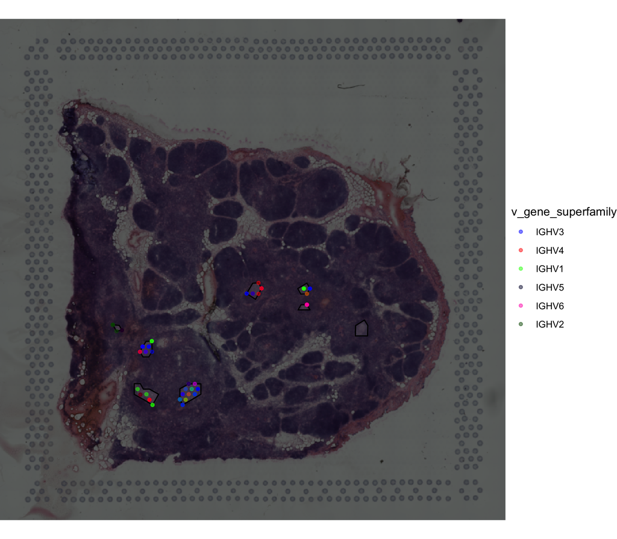

```r
gc_v_gene_plot
```

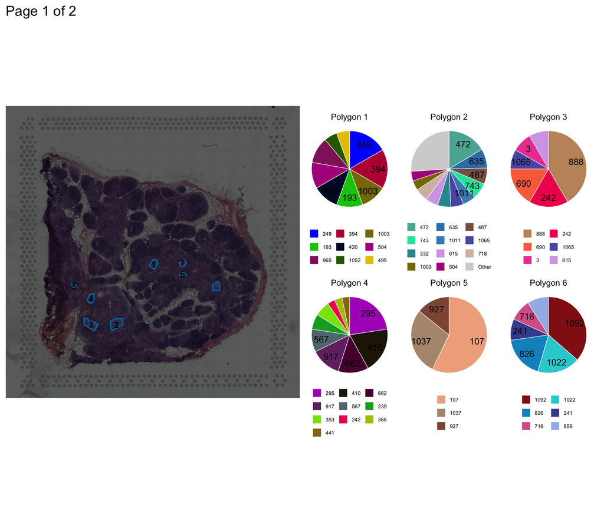

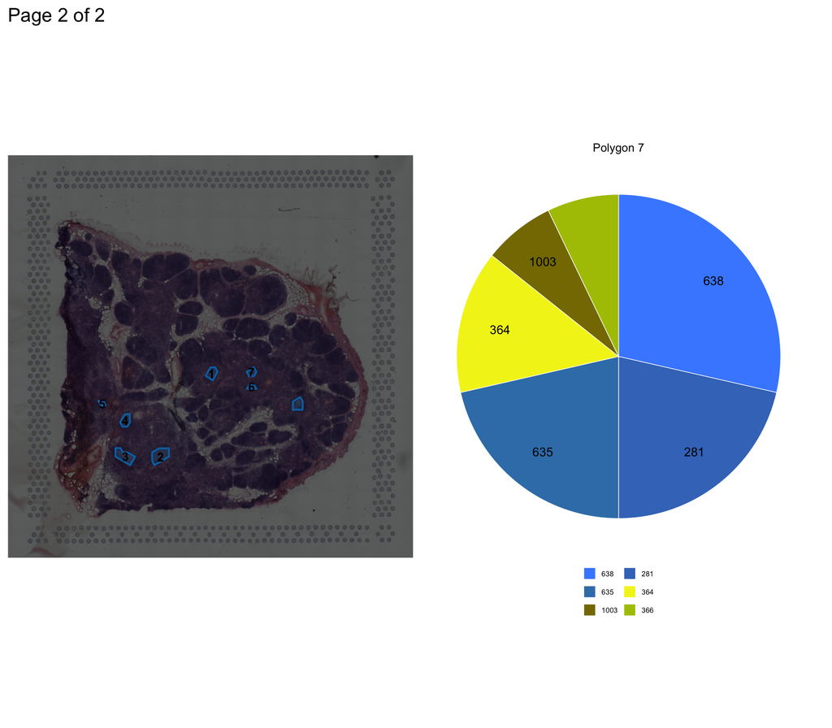

```r
gc_clone_pies <- plotSpatialPolygonPies(
  dominance = gc_clonal_dominance,
  object = mg_thymus_slice2_sirup,
  fill = "clone_id",
  mode = "side_by_side",
  top_n = 10,
  label_top_n = 5
)

gc_v_family_pies <- plotSpatialPolygonPies(
  dominance = gc_clonal_dominance,
  object = mg_thymus_slice2_sirup,
  fill = "v_gene_superfamily",
  mode = "spatial_clipped",
  top_n = 10,
  label_top_n = 1
)
gc_clone_pies
```

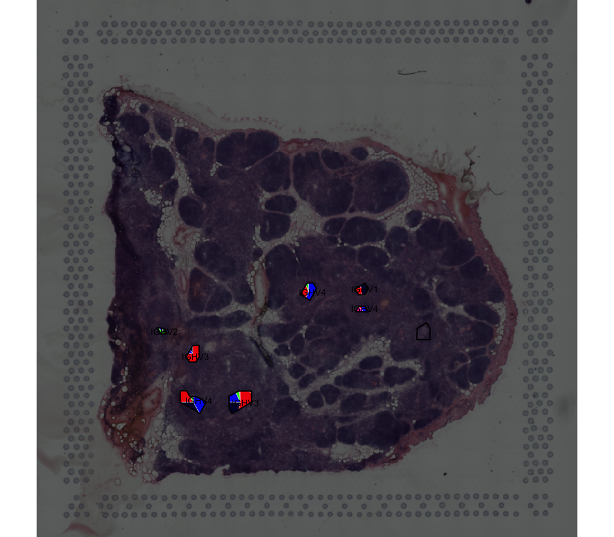

```r
gc_v_family_pies
```

We can also make 3D density plots but not in the vignette. They’re pretty janky but also pretty fun.

```r
plotSpatialCloneDensity3D(
  dominance = gc_clonal_dominance,
  object = mg_thymus_slice2_sirup,
  polygon_val = unique(gc_clonal_dominance$polygons$polygon)[1],
  top_n = 10,
  plot_type = "density",
  show_polygon = TRUE,
  as_widget = TRUE
)
```

# 15 Build and plot trees

We’ll grab some of the dominant clones from the above plot and build trees for them. Tree building needs germline sequences first, so the SIRUP workflow is to add germlines to the receptor table by using `updateReceptors()` to call dowser’s `createGermlines()`, make formatted clones with with `formatSpatialClones()` (arguments are `object` for the SIRUP object and `analysis_name` for the name of the analysis to save the formatted clones under, everything else is just the arguments from formatClones), and then build trees with `getSpatialTrees()` (arguments are `object` for the SIRUP object, `f_clones_analysis` for the analysis slot with the formatted clones, and `analysis_name` for the name of the analysis to save the formatted clones under, everything else is just the arguments from getTrees.

Here I use a temporary SIRUP object called `tree_sirup` so that we only build trees for the few clones we want to show in the walkthrough. Then I stick those trees in the main SIRUP object.

```r
tree_clone_ids <- c("249", "295", "1065")

tree_path <- file.path(walkthrough_dir, "mg_thymus_slice2_bcr_trees.rds")

tree_sirup <- updateReceptors(
  mg_thymus_slice2_sirup,
  dplyr::filter,
  clone_id %in% tree_clone_ids
)

refs <- readIMGT(dir = "/Volumes/HoehnK/Hunter/germlines/imgt/human/vdj")
```

```
## [1] "Read in 1198 from 17 fasta files"
```

```r
tree_sirup <- updateReceptors(
  tree_sirup,
  dowser::createGermlines,
  references = refs,
  id = "sequence_id"
)

tree_sirup <- formatSpatialClones(
  tree_sirup,
  analysis_name = "f_clones",
  id = "sequence_id",
  germ = "germline_alignment",
  traits = "barcode_10x"
)

tree_sirup <- getSpatialTrees(
  tree_sirup,
  f_clones_analysis = "f_clones",
  analysis_name = "trees",
  nproc = 1
)

bcr_trees <- getAnalysis(tree_sirup, "trees")

# Then add to original sirup object so we're not carrying forward the tiny one
mg_thymus_slice2_sirup <- setAnalysis(
  mg_thymus_slice2_sirup,
  "trees",
  bcr_trees
)

listAnalyses(mg_thymus_slice2_sirup)
```

```
## [1] "morans_i"                 "local_morans_i"
## [3] "ripley_gc_b_tfh"          "clone_join_count"
## [5] "polygon_receptor_summary" "gc_clonal_dominance"
## [7] "trees"
```

`plotSpatialCloneTreePairs()` takes dowser trees and makes matched tree/spatial plot pairs for each clone. For a given clone, it pulls the tree, matches tree tips back to the clone data using tip IDs and then assigns colors to these sequences using `assignTipColors()` (which just assigns individual colors to each distinct tip), draws the lineage tree with ggtree, and then plots the colored tips onto the tissue image as a scatter plot. The output is a named list by clone ID; each clone contains a tree plot and a spatial_clone plot. Tips that exist in the tree but do not have matching spatial IDs can still appear in the tree panel, but only spatially matched tips appear on the tissue plot. By default, tree tips with spatial data are circles and tips without spatial data are squares, which makes it easier to see how much of a tree is actually represented on the tissue.

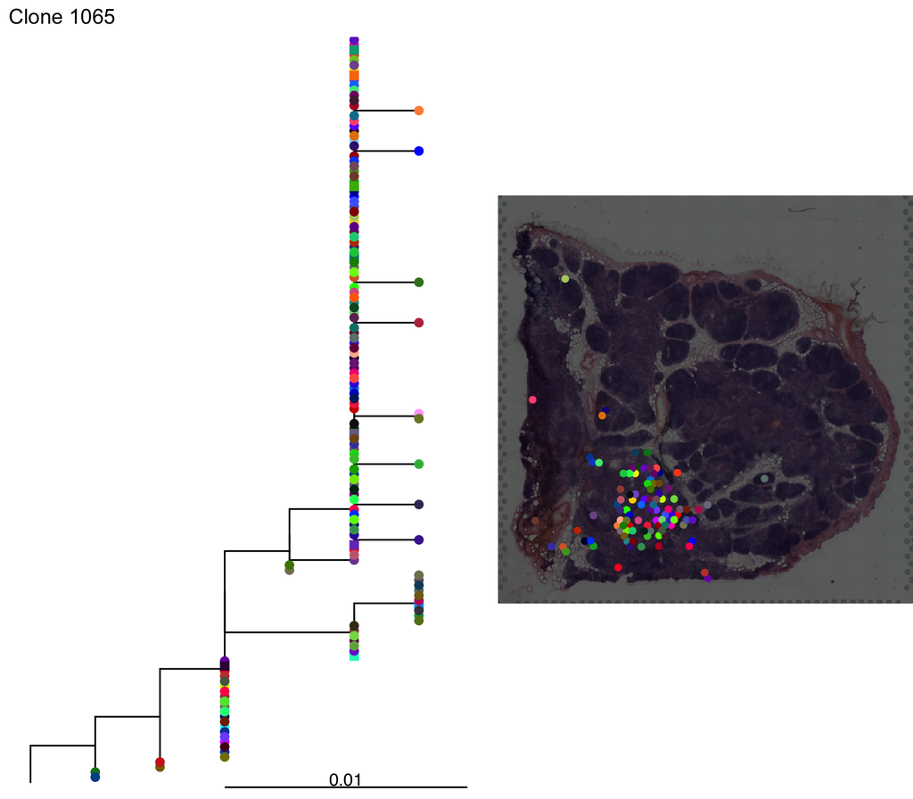

```r
tree_spatial_pairs <- plotSpatialCloneTreePairs(
  bcr_trees,
  object = mg_thymus_slice2_sirup,
  clone_val = tree_clone_ids,
  id = "sequence_id",
  treescale = 0.01,
  zoom = FALSE
)

first_tree_clone <- names(tree_spatial_pairs)[1]
cowplot::plot_grid(
  tree_spatial_pairs[[first_tree_clone]]$tree,
  tree_spatial_pairs[[first_tree_clone]]$spatial_clone,
  ncol = 2,
  rel_widths = c(1.2, 1)
)
```

We also have a function that groups tips into clusters based on different clustering methods, `clusterTreesTips()`. This just parallelizes over `clusterTreeTips()` for convenience. We cluster tips by (if `method = "split_largest_subtrees"`)

- Start with the full tree as one connected component
- For i in 1:k-1
- find all current connected tree components
- For each current component, calculate its genetic span as the largest patristic distance between any two tips in that component
- Pick the current component with the largest genetic span. If tied, prefer the component with more tips
- We’ll cut a branch in that component
- If cut_terminal_edges = FALSE, first consider only internal branches, only cut one of those unless no usable ones are left
- Among valid candidate cuts (two subtrees have tips), choose the cut that maximizes the size of the smaller daughter subtree (by number of tips). If two cuts tied, choose the one with longer branch length
- Cut
- i -> i+1

If `method = "cut_largest_branches"`, we just cut the longest branches in the tree until we have `k` clusters, which will minimize within group patristic difference. Unfortunately, this method often fails to give a visually clean result, so the default is “split_largest_subtrees”.

We can either choose the number of segments `k` ourselves or do so automatically. Automatic choice of `k` is based on minimizing the mean within clusters pairwise patristic distance. Since this should go down with any cut, we require that the relative improvement of the mean within clusters pairwise patristic distance is at least `improvement_threshold`. Automated `k` choice will occur for each tree in the list.

The arguments to `clusterTreesTips()` are dowser trees `trees` , `k` (default “auto”) the number of clusters to cut into, `id` which is the column in the `trees$data@data` that matches the tip labels, `cluster` which is the name of the new column to add with the cluster id (default “tree_cluster”), `prefix` (default “tree_cluster_”) for the cluster annotations, `ignore_tips` (default “Germline”) for the names of any tips we’d like to ignore in the clustering. Sometimes we want to build trees where not all of the tips are spatial, so we don’t want the clustering to affect the nonspatial tips. Use `keep` to specify if there is a column with information that demarcates the tips we don’t want to cluster, and `keep_val` for the values in `keep` that shouldn’t be included in the cluster assignments (really they are included in clustering then the `keep_val` overrides the cluster value). As described above, `method` can be either “split_largest_subtrees” (the default) or “cut_largest_branches”. When cutting branches, if `cut_terminal_edges` is FALSE (default TRUE) then we’ll cut non-terminal branches first, otherwise we don’t worry about it. If `k` is “auto”, we also have `k_range` (default 1:8) for the numbers of clusters to try and `improvement_threshold` (default 0.1) for the minimum relative improvement in mean within clusters patristic distance to continue cutting.

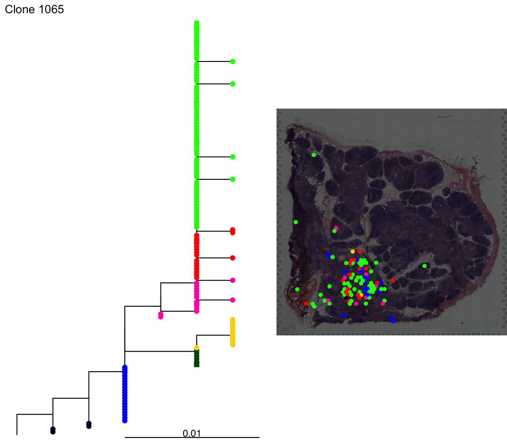

```r
clustered_bcr_trees <- clusterTreesTips(
  bcr_trees,
  k = "auto",
  id = "sequence_id",
  cluster = "tree_cluster",
  method = "split_largest_subtrees",
  k_range = 2:8,
  cut_terminal_edges = FALSE
)

clustered_tree_spatial_pairs <- plotSpatialCloneTreePairs(
  clustered_bcr_trees,
  object = mg_thymus_slice2_sirup,
  clone_val = tree_clone_ids,
  id = "sequence_id",
  color_by = "tree_cluster",
  treescale = 0.01,
  zoom = FALSE
)

first_tree_clone <- names(clustered_tree_spatial_pairs)[1]
cowplot::plot_grid(
  clustered_tree_spatial_pairs[[first_tree_clone]]$tree,
  clustered_tree_spatial_pairs[[first_tree_clone]]$spatial_clone,
  ncol = 2,
  rel_widths = c(1.2, 1)
)
```

```r
spatialCloneTreePairsToPDF(
  trees = clustered_bcr_trees,
  object = mg_thymus_slice2_sirup,
  file = file.path(walkthrough_dir, "mg_thymus_slice2_tree_spatial_pairs.pdf"),
  clone_val = tree_clone_ids,
  id = "sequence_id",
  color_by = "tree_cluster",
  treescale = 0.01
)
```

# 16 Additional things not discussed

- RAD stuff
- `seuratSubsetPolygon()`, which subsets a spatial Seurat object by only selecting points in a polygon. I used this in the analysis for the paper so we can look at gex differences between ectopic and tonsil GCs.
- The whole SpaceD heavy/light chain pairing. I think this deserves its own vignette for when the package is published, but I didn’t include it here because I don’t believe it’s as appropriate for Visium data as it is for VisiumHD data.